# Mieten in Deutschland

Worin liegen Probleme und Schwierigkeiten im deutschen Mietmarkt

# Motivation

Die Mietpreise in Deutschland spielen eine wichtige Rolle für eine Vielzahl der deutschen Bevölkerung, doch nicht alle Gemeinden sind gleichermaßen von hohen Mieten betroffen. Faktoren wie die Lage einer Stadt, das Angebot an Wohnraum, das Alter der Gebäude oder der Familienstand der Bewohner beeinflussen die Höhe der Mieten. Dies werden Sie in diesem Projekt anhand von Zensus-Daten auf Gemeindeebene für das Jahr 2022 genau untersuchen. Besonders interessant ist dabei, wie sich Mietpreise nicht nur zwischen verschiedenen Städten, sondern auch innerhalb einer Stadt unterscheiden. Sie werden feststellen, dass die Ursachen für diese Mietunterschiede komplex und vielschichtig sind. Ihre Aufgabe ist es, durch fundierte Analysen herauszuarbeiten, welche Faktoren den größten Einfluss auf die Mietentwicklung haben. Auf Basis dieser Erkenntnisse könnten Sie Handlungsempfehlungen geben, die Politik und Stadtplaner nutzen können, um die Mietpreisentwicklung besser zu steuern und Wohnraum gerechter zu gestalten.

# Datengrundlage

In diesem Projekt werden Sie mit mehreren unterschiedlichen Datensätzen arbeiten. Zum Einen werden Sie Zensusdaten aus dem Jahr 2022 zur Demografie genauer betrachten. Zum Anderen werden Sie Daten zur Wohnungszählung in deutschen Gemeinden und Städten untersuchen. Schließlich benötigen Sie die dazugehörigen Kartendaten, um die Informationen später anschaulich visualisieren zu können. Dort werden Sie die Details der Karten einlesen und darüber hinaus Zahlen zu Mieten selbstständig herunterladen und importieren.

## Einlesen

Mittlerweile wohnen knapp 54% der Menschen in Deutschland zur Miete (Stand 2022). Somit ist Deutschland das Mieterland Nummer 1 in Europa. Im Vergleich dazu haben Länder wie Frankreich (36,6%), Italien (25,7%) oder Spanien (24%) einen deutlich geringeren Anteil an Mietern. Für die Politik ist es besonders interessant zu erfahren, wie sich nun die Mieten in den unterschiedlichen Gemeinden in Deutschland verteilen und ob es Regionen gibt, wo es besonders schwer wird eine neue Wohnung zu finden. Um dies zu beleuchten, sollen Sie nun die nachfolgenden Datensätze genauer analysieren.

1. Lesen Sie den Datensatz `Demografie_Zensus.csv` ein und speichern diesen als `demografie`. Der Datensatz `demografie` enthält für jede Gemeinde mehrere Beobachtungen. Dies liegt daran, dass für jede Altersgruppe der Personen eine eigene Beobachtung vorliegt. Allerdings ist der Datensatz im long-Format, d.h. nicht tidy und damit nicht so, wie Sie ihn für die weitere Datenanalyse benötigen. Nun soll der Datensatz so abgeändert werden, dass jede Gemeinde nur noch eine Beobachtung darstellt. Passen Sie den Datensatz so an, dass Sie für jede `Altersgruppe` eine eigene Spalte erstellen und dort jeweils die Anzahl der Menschen, die Sie der Spalte `Anzahl pro Altersgruppe` entnehmen können, eingetragen wird.

Darüberhinaus sollen Sie nun einen weiteren Datensatz `Wohnungen_Zensus.csv` einlesen, welcher Informationen zu den einzelnen Wohnungen in den Gemeinden enthält. Speichern Sie den Datensatz in der Variable `wohnungen` ab. Vereinen Sie ihren Datensatz `demografie` mit dem Datensatz `wohnungen` und speichern Sie diesen als `zensus_daten` ab. Verwenden Sie für ihren “Join” die Variable `Regionalschlüssel`.

Beantworten Sie anschließend die Frage, welche Art von “Join” sich in diesem Fall anbietet und warum?

Wir möchten in diesem Teil der Analyse nur Informationen über Gemeinden betrachten, für die sowohl demografische als auch wohnungsbezogene Daten vorliegen. Gemeinden ohne Übereinstimmug in einem der Datensätze sind irrelevant für die Analyse und sollten ausgeschlossen werden. Der Inner Join eignet sich dafür ideal, da er nur Daten kombiniert, bei denen der Regionalschlüssel in beiden Datensätzen identisch ist. Dadurch verhindert er außerdem, dass Daten keine unvollständigen Beobachtungen enthalten, denn wie schon erwähnt, werden unvollständige Daten rausgeschmissen und nicht mit NA ergänzt.

2. Schränken Sie nun Ihren erstellten Datensatz auf folgende Variablen ein:
- `Name_Gemeinde`
- `Landkreis`
- `0_Insgesamt_`
- `Regionalschlüssel`
- `Alter_infr__` (01 bis 11)
- `FAMSTND_KURZ__` (1 bis 5)
- `Einwanderungserf_ausf__1`
- `Einwanderungserf_ausf__21`
- `Einwanderungserf_ausf__22`
- `Einwanderungserf_ausf__3`
- `Staatsange_kurz__1`
- `Staatsange_kurz__2`
- `BAUJAHR_10JA__` (01 bis 10)
- `WOHNFLAECHE_20S__` (01 bis 10)
- `QMMIETE`
- `LEQ`
- `ETQ`
- `FLAECHE`
- `Wohnungen_gesamt`

Beschreiben Sie weiterhin den Datensatz. Orientieren Sie sich hierbei an folgenden Fragen und nutzen Sie das bereitgestellte README zum Datensatz:

- Was ist eine Beobachtung?
- Wie viele Variablen hat der Datensatz?
- Welche Variablen enthält der Datensatz? Bitte beschreiben Sie diese Variablen kurz!
- Welche Städte mit mehr als 500.000 Einwohnern sind im Datensatz?
- In wie viel Prozent der Fälle haben Sie Informationen zu allen Variablen einer Beobachtung?

Der Datensatz zensus_daten enthält insgesamt 51 Variablen und 10.786 Beobachtungen. Eine Beobachtung gibt in diesem Fall Aufschluss über eine Gemeinde in Deutschland, deren individuellen Regionalschlüssel, sowie dem zugehörigen Landkreis.

Der Datensatz enthält umfangreiche demografische Informationen über die Gemeinden. Dazu gehört die Gesamtbevölkerungszahl sowie eine detaillierte Aufschlüsselung der Bevölkerung nach Altersgruppen, von Kleinkindern unter 3 Jahren bis hin zu Personen ab 75 Jahren. Zudem wird die Bevölkerung nach Familienstand differenziert, einschließlich Kategorien wie ledig, verheiratet, verwitwet oder geschieden. Des weiteren enthält der Datensatz Angaben zur Einwanderungsgeschichte, wobei zwischen Personen ohne Einwanderungsgeschichte, eingewanderten Personen, Nachkommen von Eingewanderten sowie Personen mit einseitiger Einwanderungsgeschichte unterschieden wird. Schließlich werden auch die Staatsangehörigkeiten unterschieden, mit einer Aufteilung in Personen mit deutscher und ausländischer Staatsangehörigkeit.

Anschließend beinhaltet der Datensatz wohnungsbezogene Informationen, darunter die Gesamtzahl der Wohnungen in jeder Gemeinde, sowie deren Baujahre und Wohnflächen. Die Baujahre sind in Jahrzehnte unterteilt, angefangen von vor 1919 bis zu 2016 und später. Die Wohnflächen der Wohnungen sind ebenfalls in Kategorien gegliedert, von weniger als 40 m² bis zu 200 m² und mehr. Zusätzlich gibt der Datensatz Auskunft über die durchschnittliche Nettokaltmiete pro Quadratmeter, die Leerstandsquote (prozentualer Anteil der leerstehenden Wohnungen) und die Eigentümerquote (prozentualer Anteil der von Eigentümern bewohnten Wohnungen). Schließlich wird die durchschnittliche Wohnungsgröße in Quadratmetern angegeben, die das Verhältnis der Gesamtfläche zur Anzahl der Wohnungen widerspiegelt. In dem Datensatz sind 15 der 10.786 Gemeinden mit mehr als 500.000 Einwohnern, angeführt von Berlin und gefolgt von Hamburg, München, Köln, Frankfurt, Düsseldorf, Stuttgart, Leipzig, Dortmund, Bremen, Essen, Dresden, Nürnberg, Hannover und Duisburg, enthalten.

Insgesamt bietet der Datensatz durch die Abdeckung von Gemeinden aller Größenordnungen ein vollständiges Bild Deutschlands, von kleinen Gemeinden bis hin zu Metropolen. Zusätzlich sind in 98,591% der Fälle Daten zu allen variablen einer Gemeinde vorhande, was den Datensatz für Analysen aus unserer Sicht tauglich macht.

3. Erstellen Sie in einem nächsten Schritt weitere Variablen, die Sie in ihrer Analyse benötigen. Diese Variablen sollen folgende Eigenschaften umfassen:
- Je eine Variable für den Anteil kleiner, mittlerer und großer Wohnungen, wobei kleine Wohnungen (<= 59 m²), mittlere Wohnungen (60 - 159 m²) und große Wohnungen (>= 160 m²) als Anteil an den `Wohnungen_gesamt` abgebildet werden sollen.
- Je eine Variable für den Anteil neuer und alter Wohnungen. Neue Wohnungen umfassen alle Wohnungen, die ab 2010 gebaut wurden und alte Wohnungen sind alle Wohnungen vor 1950. Auch hier soll wieder der Anteil an allen Wohnungen (`Wohnungen_gesamt`) berechnet werden.
- Das Verhältnis von Personen mit deutscher Staatsangehörigkeit zu allen Bürgern der Gemeinde einschliesslich Personen mit ausländischer Staatsangehörigkeit und Personen mit dem Status “staatenlos”, “ungeklärt” und “ohne Angabe” über `Staatsange_kurz__1` und `Staatsange_kurz__2`. Hier soll der Anteil deutscher Bürger im Verhältnis zu allen Bürgern der Gemeinde bestimmt werden.

*Hinweis:* Runden Sie die Werte für die neu erstellte Variable sinnvoll!

4. Um Karten wie bspw. in der Case Study zu erstellen, benötigen Sie Kartendaten in Form von Shapefiles (Endung .shp). In einer späteren Analyse sollen Sie die einzelnen Städte, bzw. deren Bezirke visualisieren. Hierzu müssen Sie zuerst die nötigen Shape-Files einlesen und Details zu den einzelnen Bezirken herunterladen. Sie sollen Analysen auf Basis von 1km Gitterdaten durchführen. Deshalb sollten Sie sich [diese Geogitter-Daten für die Nettokaltmieten vom statistischen Bundesamt herunterladen](https://www.zensus2022.de/static/Zensus_Veroeffentlichung/Zensus2022_Durchschn_Nettokaltmiete.zip). Speichern Sie die zip-Datei im Ordner `Daten` ab. Weiterhin sollen Sie [die Geogitter-Daten für die Leerstandsquoten herunterladen](https://www.zensus2022.de/static/Zensus_Veroeffentlichung/Marktaktive_Leerstandsquote_in_Gitterzellen.zip). Speichern Sie auch diese im Ordner `Daten` ab und lesen Sie anschließend die .csv-Dateien für Nettokaltmiete und Leerstandsquote (für das 1km-Gitter) ein. Weiterhin benötigen Sie die Karteninformationen für die Visualisierung der Daten. Diese befinden sich in der Datei `Shapefile_Zensus.shp`. Lesen Sie diese mit Hilfe von `st_read()` ein und speichern Sie als `shape_file` ab. Benennen Sie die Variablen in `shape_file` folgendermaßen um:
- gemndnm = Name_Gemeinde
- x_mp_1k = x_mp_1km
- y_mp_1k = y_mp_1km
- gttr1km = gitter1km

Joinen Sie nun noch die beiden Dataframes zu Miete und Leerstandsquote zu `shape_file` hinzu. Verwenden Sie `y_mp_1km` und `x_mp_1km` als Joinvariable.

*Hinweis:* Im ersten Teil der Case-Study wird eine ZIP-Datei in R entpackt. Gehen Sie hier gleich vor!

# Konsistenzcheck

Nun haben Sie alle Daten zusammen, die Sie für die Analyse der Mieten in Deutschland für das Jahr 2022 benötigen. Somit können Sie nun beginnen, die ersten Analysen zu tätigen!

5. Im Datensatz `zensus_daten`, welchen Sie zuvor eingelesen, aufgearbeitet und zusammengefügt haben, befinden sich einige große deutsche Städte. Sie möchten nun gerne die Daten, welche Sie dort aufbereitet haben, verifizieren. Dafür sollten Sie sich eine externe Quelle suchen, auf deren Basis Sie die Gesamtbevölkerung der unten aufgeführten großen Städte in Deutschland mit denen aus dem Datensatz vergleichen. Die Bevölkerungszahlen in ihrem Datensatz stammen aus dem Jahr 2022.

Erstellen Sie eine Tabelle mit allen nachfolgenden Städten aus dem Datensatz und deren Einwohnern. Achten Sie auf eine schöne Darstellung ihrer Tabelle mittels der Pakete `kableExtra` oder `gt`.

Im Detail sollen folgende Städte in der Tabelle genauer betrachtet werden:

- “Berlin, Stadt”, “Hamburg, Freie und Hansestadt”, “München, Landeshauptstadt”, “Köln, Stadt”, “Frankfurt am Main, Stadt”, “Stuttgart, Landeshauptstadt”, “Düsseldorf, Stadt”, “Leipzig, Stadt”, “Augsburg”, “Ingolstadt”, “Ulm, Universitätsstadt”, “Reutlingen, Stadt”

Sind die Anzahl der Einwohner in ihren Daten korrekt? Nutzen Sie eine externe Datenquelle (bitte benennen und in ihrer Antwort verlinken) und führen Sie einen kurzen Konsistenzcheck durch.

Übersicht der Bevölkerung in ausgewählten Städten

| Stadt | Bevölkerung Data | Statistisches Bundesamt | Differenzen |
| --- | --- | --- | --- |
| Augsburg | 294647 | 301033 | -6386 |
| Berlin, Stadt | 3596999 | 3755251 | -158252 |
| Düsseldorf, Stadt | 611258 | 629047 | -17789 |
| Frankfurt am Main, Stadt | 743268 | 773068 | -29800 |
| Hamburg, Freie und Hansestadt | 1808846 | 1892122 | -83276 |
| Ingolstadt | 136468 | 141029 | -4561 |
| Köln, Stadt | 1017355 | 1084831 | -67476 |
| Leipzig, Stadt | 598899 | 616093 | -17194 |
| München, Landeshauptstadt | 1478638 | 1512491 | -33853 |
| Reutlingen, Stadt | 116925 | 117547 | -622 |
| Stuttgart, Landeshauptstadt | 610458 | 632865 | -22407 |
| Ulm, Universitätsstadt | 127116 | 128928 | -1812 |

# Deskriptive Analysen

6. Schauen Sie sich in einem nächsten Schritt an, wie die Variablen im Datensatz `zensus_daten` über alle Gemeinden und Städte hinweg verteilt sind. Konkret sollten Sie eine Tabelle erstellen, welche Informationen zu folgenden Variablen enthält:
- verschiedene Baujahre der Wohnungen
- durchschnittlicher Quadratmeterpreis
- Leerstandsquote
- Eigentümerquote
- durchschnittliche Wohnfläche
- Anteil kleiner, mittlerer und großer Wohnungen
- Einwohner

Berechnen Sie zu jeder Variablen den Mittelwert, den Median, das Minimum, das Maximum, die Standardabweichung, sowie das 25%- und das 75%- Quantil bezogen auf alle Gemeinden. Bei den Variablen Leerstandsquote, Eigentümerquote, durchschnittliche Wohnfläche, durchschnittlicher Quadratmeterpreis und Anteil kleiner, mittlerer und großer Wohnungen soll der Mittelwert als gewichteter Mittelwert nach der absoluten Anzahl an Wohnungen berechnet werden. Heben Sie die Variablen in ihrer Tabelle entsprechend hervor, bei denen sie den gewichteten Mittelwert bestimmt haben.

Beschreiben und interpretieren Sie Ihre Tabelle. Begründen Sie auch, warum es bei den genannten Variablen sinnvoll ist, den nach Anzahl der Wohnungen gewichteten Mittelwert zu verwenden. Würde es ihrer Ansicht nach Sinn machen, statt nach Wohnungen nach Einwohnern zu gewichten? Begründen Sie auch, bei welchen Variablen eine Betrachtung der Mittelwerte, Standardabweichungen und Quantile ihrer Ansicht nach als sinnvoll erscheint. Wo ist dies weniger gut geeignet? Bei welchen Variablen gibt es Auffälligkeiten? Gibt es Ausreißer nach oben oder unten?

Achten Sie auf eine schöne Darstellung ihrer Tabelle mittels der Pakete `kableExtra` oder `gt`!

*Hinweis 1:* Wenn bei den Variablen Wohnungen_klein, Wohnungen_mittel und Wohnungen_groß Werte mit `NaN` oder `Inf` auftauchen, so ersetzen Sie diese durch `NAs`.

*Hinweis 2:* Die Anzahl der Wohnungen nach Alters- bzw. Baujahrsgruppen können den Variablen entnommen werden, welche mit `BAUJAHR_10JA__` beginnen.

Variableninformation<sup>1</sup>

Deskriptive Statistiken

| Variable | Mittelwert | Standardabweichung | Minimum | 25% Quantil | Median | 75% Quantil | Maximum |
| --- | --- | --- | --- | --- | --- | --- | --- |
| vor 1919 | 527.59 | 5,692.47 | 0.00 | 50.00 | 111.00 | 316.00 | 520,700.00 |
| 1919-1949 | 410.88 | 3,526.98 | 0.00 | 28.00 | 69.00 | 221.00 | 281,150.00 |
| 1950-1959 | 458.39 | 3,943.25 | 0.00 | 20.00 | 60.00 | 198.00 | 193,475.00 |
| 1960-1969 | 608.00 | 4,351.18 | 0.00 | 30.00 | 94.00 | 337.50 | 261,728.00 |
| 1970-1979 | 579.82 | 3,426.96 | 0.00 | 33.00 | 113.00 | 388.50 | 239,857.00 |
| 1980-1989 | 395.81 | 2,676.07 | 0.00 | 29.00 | 91.00 | 295.00 | 223,683.00 |
| 1990-1999 | 479.42 | 2,131.73 | 0.00 | 39.00 | 124.00 | 407.00 | 141,456.00 |
| 2000-2009 | 251.93 | 1,114.23 | 0.00 | 23.00 | 69.00 | 204.00 | 57,008.00 |
| 2010-2015 | 129.78 | 828.19 | 0.00 | 8.00 | 26.00 | 88.00 | 45,389.00 |
| nach 2016 | 155.93 | 1,101.49 | 0.00 | 9.00 | 33.00 | 115.00 | 80,878.00 |
| QMMIETE | 5.75 | 1.38 | 0.00 | 4.82 | 5.53 | 6.46 | 13.84 |
| LEQ | 5.39 | 3.11 | 0.00 | 3.45 | 4.74 | 6.58 | 50.00 |
| ETQ | 67.22 | 12.72 | 13.49 | 60.22 | 68.77 | 76.11 | 100.00 |
| FLAECHE | 114.61 | 15.41 | 64.92 | 104.98 | 116.20 | 125.11 | 239.54 |
| Wohnungen_gesamt | 3,996.54 | 27,478.25 | 0.00 | 326.00 | 877.00 | 2,743.75 | 2,018,832.00 |
| kleine_Wohnungen | 0.11 | 0.08 | 0.00 | 0.06 | 0.09 | 0.14 | 0.59 |
| mittlere_Wohnungen | 0.57 | 0.09 | 0.00 | 0.54 | 0.59 | 0.63 | 1.00 |
| große_Wohnungen | 0.17 | 0.08 | 0.00 | 0.11 | 0.16 | 0.21 | 1.00 |
| Einwohner | 7,668.39 | 49,519.18 | 9.00 | 655.25 | 1,797.00 | 5,505.00 | 3,596,999.00 |

<sup>1</sup> Graue Zeilen sind gewichtete Mittelwerte.

Gewichtete Mittelwerte können Sinn machen, wenn gewisse Werte in den Daten häufiger vorkommen und somit das Gesamtbild verzerren würden. Für unseren Datensatz wäre das beispielsweise der Fall, wenn es in einer Stadt deutlich mehr große als kleine Wohnungen geben würde. Dadurch würde das zu sehr ins Gewicht fallen.

7. Die Verteilung des Alters der Wohnungen scheint bereits ein Faktor zu sein, der sich auf den Mietpreis auswirken kann, da doch deutlich weniger Wohnungen ab den 2000er Jahren gebaut wurden. Nun sollen Sie etwas tiefer in ihren Datensatz eintauchen und weitere Faktoren analysieren, die sich zum einen zwischen Städten und Gemeinden unterscheiden und darüberhinaus herausfinden, ob diese Faktoren einen Einfluss auf den Mietpreis haben:

Erstellen Sie 4 Punktdiagramme in denen Sie

- die durchschnittliche Fläche je Wohnung,
- die Leerstandsquote je Gemeinde,
- Anteil alter Wohnungen je Gemeinde,
- Anteil neuer Wohnungen je Gemeinde,

auf der x-Achse abtragen und auf der y-Achse jeweils die durchschnittliche Nettokaltmiete pro Quadratmeter. Verwenden Sie hier nun alle Gemeinden im Datensatz, um ein Gesamtbild zu erhalten und ordnen Sie die 4 Diagramme so an, dass ein Vergleich zwischen den Schaubildern schnell und einfach möglich ist. Beschreiben und interpretieren Sie die Diagramme. Gehen Sie hierbei insbesondere auf folgende Fragen ein:

- Welche Variablen scheinen besonders stark mit dem Mietpreis korreliert zu sein?
- Was könnte die Zusammenhänge erklären?

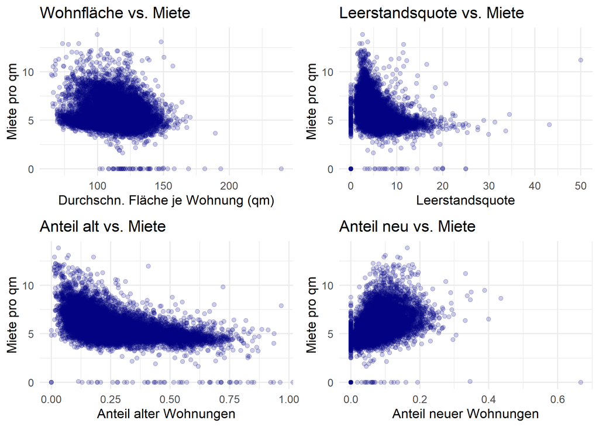

Das Punktdiagramm 1 deutet an, dass kleinere Wohnungen tendenziell höhere Mietpreise pro Quadratmeter haben. Folglich kann man bei größeren Wohnungen eine Tendenz zu geringeren Quadratmeterpreisen beobachten. Grund dafür könnte sein, dass Wohnungen in der Stadt meist teurer und auch kleiner sind, aber auch die Zahlungsbereitschaft pro weiterem Quadratmeter abnimmt (abnehmender Grenznutzen).

Diagramm 2 zeigt, dass viele leerstehende Wohnungen mit geringeren Quadratmeterpreisen einhergehen. In jenen Gemeinden ist die Nachfrage gering, was zu niedriger Auslastung und geringem Preis führt. Somit ist eine negative Korrelation zwischen Leerstandsquote und Mietpreis klar zu erkennen.

Weiterhin wäre es von Interesse in die einzelnen Großstädte Deutschlands genauer hineinzuschauen, um dort auf Besonderheiten im Wohnmarkt einzugehen. Im ersten Schritt sollen Sie Eigenschaften in Bezug auf die Wohnungen genauer untersucht werden, um zu verstehen, welche Faktoren den Mietpreis innerhalb der urbanen Räume beeinflussen könnten. Anschließend wäre es von Interesse, auch die demografischen Merkmale der Mieterinnen und Mieter in den Blick zu nehmen. Dabei stellt sich die Frage, ob und in welchem Maße diese Einfluss auf die Mietpreise und deren Struktur nehmen.

In der vorherigen Aufgabe wurden Zusammenhänge zwischen dem Alter von Wohnungen und dem Mietpreis auf Gemeindeebene untersucht. Nun soll der Fokus darauf liegen, wie sich die Wohnungen in größeren Städten hinsichtlich ihres Alters verteilen.

8. Erstellen Sie ein Balkendiagramm für alle nachfolgenden Städte: `Stuttgart, Landeshauptstadt`, `Ulm, Universitätsstadt`, `Düsseldorf, Stadt`, `Berlin, Stadt`. Betrachten Sie dabei, wie das Alter der Wohnungen zwischen den Städten variiert. Sie sollen analysieren, wie groß der Anteil der Wohnungen abhängig nach den jeweiligen Baujahrsgruppen in den Städten ist. Tragen Sie in ihrem Balkendiagramm den *Anteil der Wohnungen nach den Baujahren* (auf der y-Achse) gegeben der *Baujahre für jede Stadt* (auf der x-Achse) ab.

Beschreiben und interpretieren Sie die Grafik. Haben Sie diese Unterschiede erwartet? Begründen Sie warum oder warum nicht.

*Hinweis:* Denken Sie daran das Faktorvariablen in ggplot hilfreich sein können.

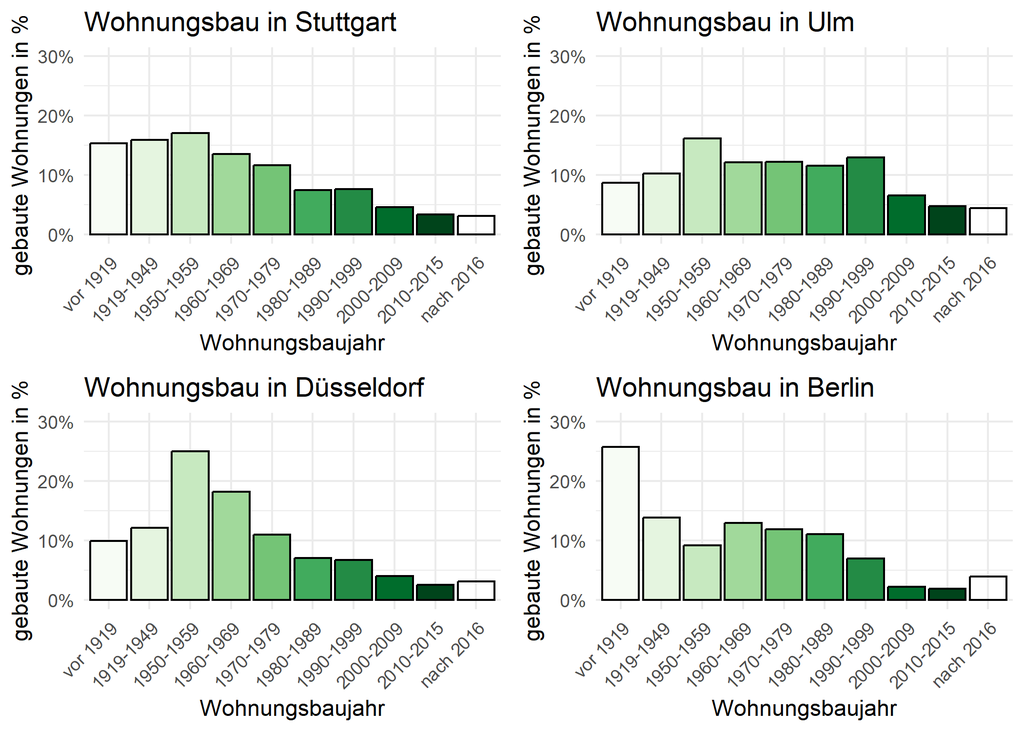

Die Diagramme zeigen die prozentuale Verteilung des Wohnungsbaus nach Baujahren in Stuttgart, Ulm, Düsseldorf und Berlin. Es fällt auf, dass in Berlin circa 25% der heutigen Wohnungen vor 1919 gebaut wurden, was die Ästhetik mit den Altbauwohnungen in Berlin ideal beschreibt. Zudem zeigt die Grafik in Stuttgart, Ulm und Düsseldorf Auffälligkeiten in den Jahren von 1950-1959. Insbesondere Düsseldorf verzeichnet in diesem Zeitraum einen steilen Anstieg im Wohnungsbau, was darauf zurückzuführen ist, dass Düsseldorf im 2.Weltkrieg fast vollständig zerstört wurde. Laut wikipedia waren in der Kernstadt 93 % aller Wohnhäuser, 96 % der öffentlichen und 93 % der Geschäftsgebäude zerstört oder beschädigt (https://de.wikipedia.org/wiki/Luftangriffe_auf_D%C3%BCsseldorf). Ähnliche Geschehnisse sind auch in Stuttgart und Ulm zu beobachten, die ebenfalls durch die Kriegszerstörungen stark betroffen waren und in der Nachkriegszeit wieder aufgebaut wurden.Ein anderes Bild zeigt sich in Berlin, denn obwohl sie in dieser Phase nominell mehr Wohnungen als die anderen Städte gebaut haben, fällt die Bauaktivität im Verhältnis zu den Jahren vor dem Krieg ab, was mit der politischen Situation zusammenhängt mit der Teilung in Ost- und Westberlin.Allgemein betrachtet ist seit 1970 ein Negativtrend in den Großstädten erkennbar, womöglich zusammenhängend mit explodierenden Baukosten oder der demografischen ENtwicklung und dem Rückgang der Geburten in Deutschland. Im Vergleich zu Stuttgart, Düsseldorf und Berlin zeigt Ulm jedoch eine konstantere Entwicklung.

9. Wie in der vorherigen Aufgabe zu sehen war, unterscheidet sich die Situation in Städten in Bezug auf die jeweiligen Baujahre der Wohnungen deutlich. Es wäre noch spannend zu sehen, ob auch das Alter der Bewohner, die Familienstände, oder die Einwanderungshistorie der Bewohner mit unterschiedlichen Mietpreisen assoziiert sind. Hier sollen Sie in einem ersten generellen Schritt ein paar demografische Faktoren einbeziehen, inwiefern diese eine Auswirkung haben. Betrachten Sie folgende Eigenschaften genauer:
- Familienstand
- Alter der Bewohner
- Einwanderungsgeschichte

Erstellen Sie eine oder mehrere passende Diagramme oder Grafiken für die in Aufgabe 8 aufgeführten Städte.

Beschreiben und interpretieren Sie diese. Haben Sie diese Unterschiede erwartet? Begründen Sie warum oder warum nicht. Wo gibt es Ihrer Ansicht nach besondere Auffälligkeiten? Warum kann es bei der unterschiedlichen Einteilung der Altersgruppen zu Problemen kommen? Was wären Möglichkeiten, um etwaige Probleme zu vermeiden?

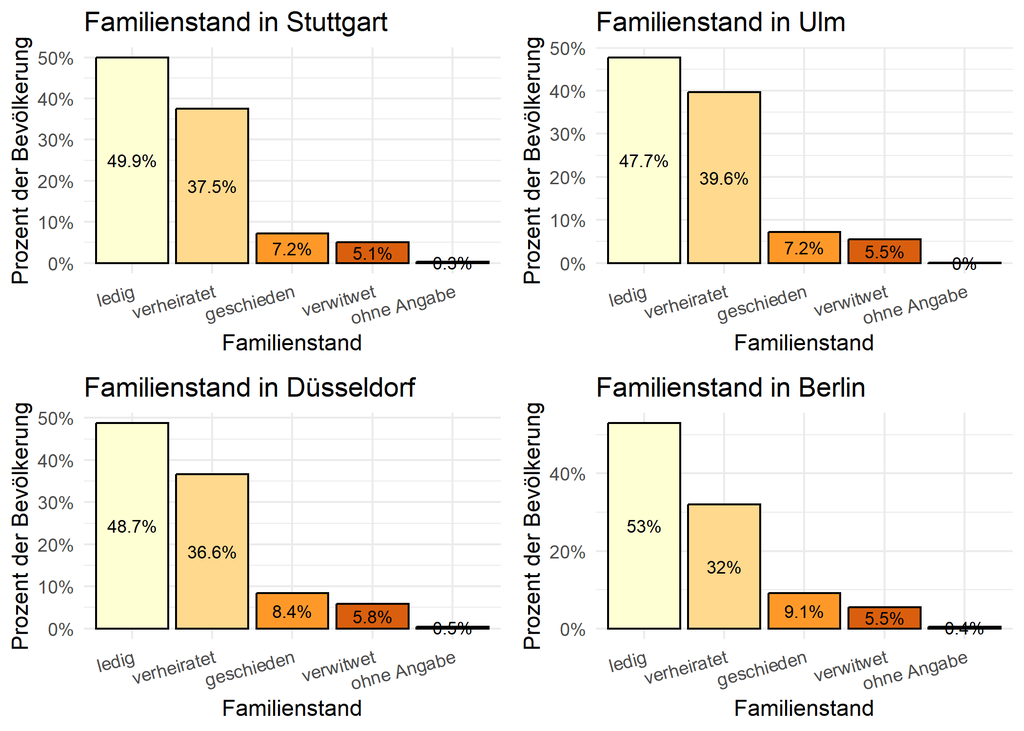

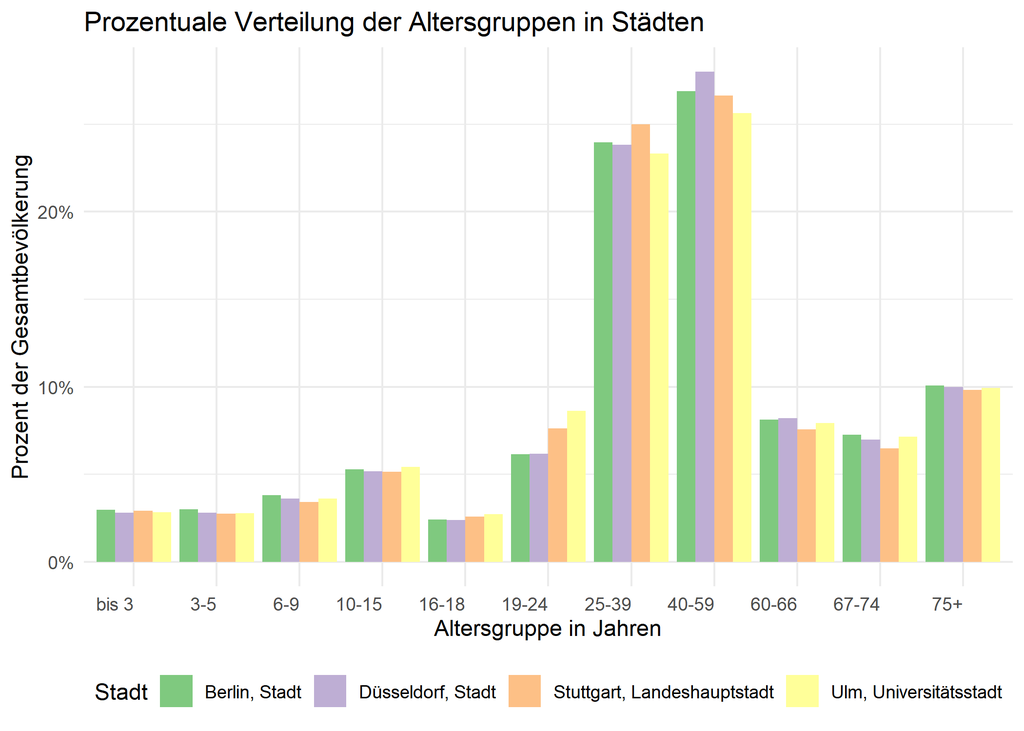

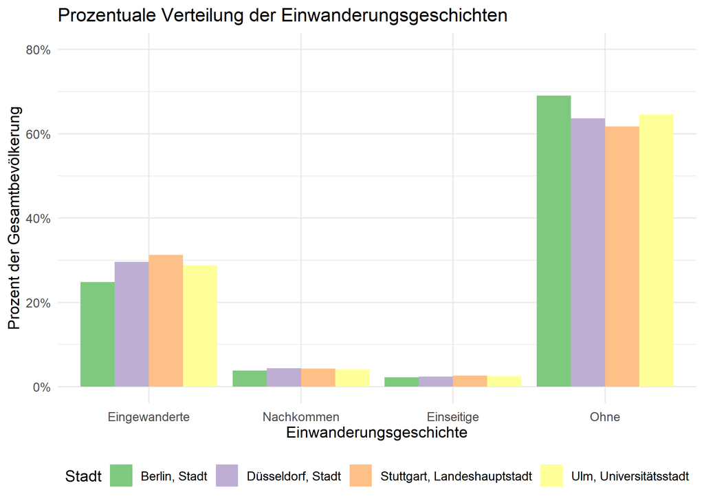

Die 4 aufgeführten Großstädte zeigen in Bezug auf den Familienstand eine relativ ähnliche Verteilung. In allen Städten dominiert der Anteil der ledigen Personen, der nahe an der 50%-Marke liegt. In Berlin übersteigt dieser Anteil jedoch deutlich die 50%, was die Hauptstadt von den anderen Städten unterscheidet. Die verheirateten Personen bilden in allen Städten die zweitgrößte Gruppe und machen 30 - 40% der Bevölkerung aus, gefolgt von den geschiedenen-, mit etwa 7-10% und den verwitweten Personen mit circa 5%. Auffällig ist, dass die vergleichsweise kleinste Stadt, Ulm, den höchsten Anteil an verheirateten Personen aufweist, was auf eine traditionelle Bevölkerung hindeuten könnte.Im Gegensatz dazu hat Berlin als bevölkerungsreichste Stadt den geringsten Anteil an verheirateten Personen und die größte Differenz zwischen ledigen und verheirateten Personen, dass die Vermutung aufkommen könnte, dass die Bevölkerung Berlins deutlich jünger im Vergleich zu den anderen Städten ist. Diese Vermutung wird aber im darauffolgenden Diagramm widerlegt.

Vergleichbar mit den Ähnlichkeiten zwischen Stuttgart und Düsseldorf beim Familienstand gibt es in Hinblick auf die Altersgruppenverteilung in den vier Großstädten keine signifikanten Unterschiede. Nennenswert ist der erhöhte Anteil an 19-24-jährigen in Ulm, was dem Namen “Universitätsstadt” und die hohe Zahl an Studierenden widerspiegelt.

Betrachtet man die verschiedenen Einwanderungsgruppen in den Städten zeigt sich wieder ein ähnliches Bild, eine ähnliche Verteilung. Medial lässt es den Eindruck erwecken, dass in Berlin viele verschiedene Nationalitäten leben und auch viele Kinder und Enkel ehemaliger Gastarbeiter, weshalb man von einer höheren Quote an Eingewanderte, bzw. Nachkommen ausgehen würde. In der Grafik zeigt sich aber überraschenderweise, dass Berlin von allen 4 Städten den höchsten Anteil an Einwohnern ohne Einwanderungsgeschichte und auch den geringsten Anteil an Eingewanderten hat. Stuttgart hingegen verzeichnet einen recht hohen Anteil an Eingewanderten und deren Nachfahren; den höchsten aller betrachteten Städten. Dies könnte auf den attraktiven Arbeitsmarkt im Stuttgarter Großraum zurückzuführen sein.

In den bisherigen Analysen wurden demografische und wohnungsbezogene Faktoren in verschiedenen Städten Deutschlands untersucht. Dabei lag der Fokus darauf, wie diese Merkmale in unterschiedlichen Regionen das Mietpreisniveau und dessen Struktur beeinflussen. Aufbauend auf diesen Erkenntnissen soll der Blick nun gezielt auf den Vergleich zwischen Ost- und Westdeutschland gelenkt werden. Diese regionale Differenzierung ermöglicht es, potenzielle Unterschiede und Gemeinsamkeiten zwischen den beiden Landesteilen genauer zu analysieren. Insbesondere wird betrachtet, wie sich die Mietpreisstruktur in Ost- und Westdeutschland darstellt und ob sich hierbei spezifische Muster oder Abweichungen erkennen lassen.

10. Betrachten Sie nun die Städte `Dresden, Stadt`, `Chemnitz, Stadt`, `Stuttgart, Landeshauptstadt`, `Ulm, Universitätsstadt`,`Düsseldorf, Stadt`und `Berlin, Stadt`. Vergleichen Sie in einem ersten Schritt die Anzahl an Einwohnern, den Anteil an Menschen, die deutscher Herkunft sind, den Anteil an neuen und alten Wohnungen, sowie die durchschnittlichen Mietpreise. Erweitern Sie ihre Analyse um die durschnittlichen Wohnflächen.

Erstellen Sie für die genannten Städte eine deskriptive Tabelle. Beschreiben und interpretieren Sie diese. Beantworten Sie insbesondere folgende Fragen:

- In wie weit könnte das Alter der Wohnungen eine Rolle für den Mietpreis spielen?
- Gibt es Auffälligkeiten zwischen den einzelnen Städten in Bezug auf Herkunft der Bewohner, Einwohner und Größe der Wohnungen?
- Warum könnte es problematisch sein, wenn Sie die Städte als ein Ganzes betrachten?
- Sind Ihre Ergebnisse auf die ganze Stadt verallgemeinerbar?
- Was sind ihrer Meinung nach Faktoren, die die unterschiedlichen Mietpreise in Ost und West erklären?
- Welche Maßnahmen wären geeignet, um in Düsseldorf, Ulm und Stuttgart die Mietpreisstruktur anzupassen und bezahlbaren Wohnraum zu schaffen?

Vergleich der Städte in Ost- und Westdeutschland

| Stadt | Einwohner | Anteil deutscher Bürger in % | Wohnungen gesamt | Anteil neue Wohnungen in % | Anteil alte Wohnungen in % | Durchschnittliche Wohnfläche | Durchschnittliche Miete (€/m^2) |
| --- | --- | --- | --- | --- | --- | --- | --- |
| **Ostdeutschland** |  |  |  |  |  |  |  |
| Berlin | 3596999 | 80.5 | 2018832 | 5.9 | 39.7 | 73.22 | 7.67 |
| Chemnitz | 240078 | 90.2 | 151854 | 3.2 | 41.0 | 71.33 | 5.26 |
| Dresden | 557782 | 90.7 | 319547 | 6.6 | 39.6 | 71.24 | 6.92 |
| **Westdeutschland** |  |  |  |  |  |  |  |
| Düsseldorf | 611258 | 77.2 | 349602 | 5.8 | 22.1 | 77.56 | 9.24 |
| Stuttgart | 610458 | 74.3 | 314427 | 6.6 | 31.3 | 79.76 | 10.39 |
| Ulm | 127116 | 78.2 | 64455 | 9.3 | 19.0 | 87.64 | 8.48 |

Die Grafik liefert Wohnungsdaten zu Berlin, Chemnitz und Dresden in Ostdeutschland und Düsseldorf, Stuttgart und Ulm in Westdeutschland, dabei sind die kategorisch besten bzw. schlechtesten Werte grün bzw. rot markiert. Bei allgemeiner Betrachtung fällt auf, dass jede einzelne von den östlichen Städten (Berlin, Chemnitz und Dresden) einen höheren Anteil an deutschen Bürgern hat, als die westlichen Städte (Düsseldorf, Stuttgart, Ulm), was auf eine größere Diversität innerhalb der westlichen Städte hinweist. Des weiteren ist die durchschnittliche Wohnfläche in ostdeutschen Großstädten deutlich geringer (circa 72m^2) als in westdeutschen Großstädten (77 - 87m^2). Die Auswahl der Städte erschwert eine allgemeine Aussage zur Einwohnerzahl zu treffen.

Die Betrachtung von Städten als Ganzes ist insofern kritisch, da es in jeder Stadt relativ gesehen bessere und schlechtere, somit auch teurere und günstigere Stadtteile gibt. Angenommen in einer relativ kleinen Großstadt wie Ulm gibt es ein paar Teile, die deutlich teurer als andere sind, kann dies den Schnitt sehr verzerren, was ein trügerisches Gesamtbild zur Folge hat. Es gibt auch in jeder Stadt Teile mit höherem/niedrigerem Anteil Deutscher, kleiner Wohnungen usw. Daher wäre es oftmals sinnvoller, Städte auf Stadtteile herunterzubrechen, um Differenzen besser erkennen zu können.

Die Mietpreisdiskrepanzen zwischen Ost und West haben viele Gründe. Einerseits ist im Westen, in wirtschaftlich starken Regionen, wie Frankfurt und dem Rheingebiet eine große Auswahl an guten Arbeitsplätzen vorhanden, was die Nachfrage in diesen Regionen steigert und somit zu höheren Mietpreisen führt. Dadurch wollen auch grundsätzlich mehr Leute in Städte wie Stuttgart, Frankfurt, München, Düsseldorf und Co. ziehen. Außerdem gibt es in Westdeutschland (in den betrachteten Städten) mehr moderne Wohnungen, was die Attraktivität dieser Standorte weiter erhöht. Um die hohe Nachfrage in Stuttgart, Düsseldorf und Ulm zu bewältigen, wären mehrere Maßnahmen denkbar. Eine Möglichkeit besteht darin, durch den Bau neuer Wohnungen das Angebot zu erhöhen und so den Druck auf die Mietpreise zu mindern. Außerdem würde eine Mietpreisbremse eine Regulierungsmöglichkeit darstellen, wenngleich dies die Lukrativität neuer Bauprojekte schmälern würde, wodurch das Interessee von Bauträgern geringer wird. Ein anderer Ansatz wäre die Schaffung von Wohnraums außerhalb des Zentrums, dafür müsste die Infrastruktur aber deutlich ausgebaut werden.

11. Lesen Sie den [folgenden Artikel](https://www.tagesschau.de/wirtschaft/sozialwohnungen-bau-mangel-101.html). Dort werden Sozialwohnungen thematisiert, warum so viele fehlen und wer davon vor allem betroffen ist. Beantworten Sie anschließend folgende Fragen:
- Welche Bevölkerungsgruppen sind am stärksten von der Sozialwohnungsnot betroffen und inwiefern?
- Was sind Gründe, warum es zu wenige Sozialwohnungen gibt?
- Wie sieht die historische Entwicklung des Sozialwohnungsbaus aus, im Hinblick auf Vorhandensein von Wohnungen und Investitionen in den Bau von neuen Wohnungen?
- Welche Anreize könnten Investoren motivieren, mehr Sozialwohnungen zu bauen?
- Welche innovativen Ansätze können Bauherren verfolgen, um die Kosten für den Wohnungsbau zu senken?

Welche Bevölkerungsgruppen sind am stärksten von der Sozialwohnungsnot betroffen und inwiefern? Antwort: Ärmere Familien und finanziell schwache Wohnungssuchende sind besonders betroffen. Diese Gruppen haben aufgrund ihres Einkommensniveaus generell Schwierigkeiten, bezahlbaren Wohnraum auf dem freien Markt zu finden. Selbst diejenigen, die einen Wohnberechtigungsschein besitzen, stehen aufgrund des Mangels an Sozialwohnungen oft auf langen Wartelisten.

Was sind Gründe, warum es zu wenige Sozialwohnungen gibt?

Viele Sozialwohnungen fallen nach 25 bis 30 Jahren aus der Mietbindung, das bedeutet, dass nach Ablauf dieser Bindung die Wohnungen nicht mehr zu den vergünstigten Mietkonditionen angeboten werden müssen und häufig zu Marktpreisen vermietet werden. Zudem belasten steigende Baukosten und Zinsen die Wirtschaftlichkeit sozialer Wohnungsprojekte, die Preise für Baustoffe sind weltweit gestiegen, vor allem durch erhöhte Nachfrage und unterbrochene Lieferketten, was zum Beispiel auch Krisen wie der Ukraine-Krieg zur Folge hat. Auch die Kosten für qualifiziertes Personal in der Baubranche sind gestiegen. Außerdem erhöhen strengere Bauvorschriften, insbesondere in Bezug auf Umweltverträglichkeit und Energieeffizienz die Kosten für die Errichtung neuer Wohnbauten zusätzlich. Des weiteren gibt es aufgrund der oben gennanten Faktoren zu wenige Anreize für Investoren, da die möglichen Gewinne im Vergleich zu anderen Immobilieninvestitionen weniger attraktiv sind. Dies macht sozial geförderten Wohnungsbau weniger lukrativ. Generell wird jeder der Faktoren auch noch dadurch vertsärkt, dass die einzelen Bundesländer in Deutschland verschiedene Ideen und Förderprogramme haben, was die Zusammenarbeit der Lösungsfindungh deutlich erschwert.

Wie sieht die historische Entwicklung des Sozialwohnungsbaus aus, im Hinblick auf Vorhandensein von Wohnungen und Investitionen in den Bau von neuen Wohnungen? Die historische Entwicklung des Sozialwohnungsbaus in Deutschland zeigt einen deutlichen Rückgang sowohl im Bestand an Sozialwohnungen als auch in den Investitionen in den Neubau solcher Wohnungen. In den neunziger Jahren gab es in Deutschland etwa drei Millionen Sozialwohnungen. Diese Zahl hat sich jedoch bis heute auf rund 1,1 Millionen reduziert. Steigende Baukosten und Zinsen haben die Wirtschaftlichkeit neuer Projekte beeinträchtigt. Investoren sehen sich mit höheren finanziellen Risiken konfrontiert, sodass der Anreiz, in Sozialwohnungsbau zu investieren, geringer ist. Die in Frage 2 schon genannten Bedingungen haben dazu geführt, dass immer weniger Projekte geplant und umgesetzt werden. Trotz politischer Absichtserklärungen, den sozialen Wohnungsbau zu fördern, bleibt die Schaffung neuer Sozialwohnungen weit hinter den Zielen zurück, während der Bedarf an bezahlbarem Wohnraum weiter steigt. Die derzeitigen Maßnahmen und Investitionen reichen bislang nicht aus, um die Lücke zwischen Angebot und Nachfrage zu schließen, und so bleibt der Zugang zu Sozialwohnungen für viele nach wie vor eingeschränkt.**

Welche Anreize könnten Investoren motivieren, mehr Sozialwohnungen zu bauen? Eine zentrale Idee ist das Modell der “Wohngemeinnützigkeit”, das den Anreiz schafft, indem es Steuervorteile für Unternehmen bietet, die Wohnungen zu erschwinglichen Preisen anbieten. Dies würde die Rentabilität solcher Projekte erhöhen und könnte zu mehr Investitionen im sozialen Wohnungssektor führen. Zusätzlich ist eine Erhöhung der staatlichen Förderungen vorgesehen. Ab 2023 soll mehr staatliches Geld in den sozialen Wohnungsbau fließen, mit dem Ziel, die finanzielle Grundlage für den Bau solcher Wohnungen zu verbessern. Diese Fördermaßnahmen könnten dazu beitragen, die Finanzierungskosten zu senken und die Attraktivität von Neubauprojekten zu erhöhen. Ein weiterer vorgeschlagener Ansatz ist die Vereinfachung der regulatorischen Auflagen sowie die Beschleunigung von Genehmigungsverfahren. Der Abbau von Bürokratie und die Beschleunigung der Prozesse könnten es ermöglichen, dass Bauprojekte schneller und damit kosteneffizienter umgesetzt werden können. Dies könnte nicht nur die Baukosten senken, sondern auch das Risiko für Investoren verringern, das mit langen Wartezeiten und unsicheren Baufristen verbunden ist. Steuererleichterungen für Firmen, die Wohnungen zu günstigen Preisen anbieten, sind eine zusätzliche Möglichkeit, den Anreiz für den sozialen Wohnungsbau zu erhöhen. Diese Erleichterungen könnten die Fixkosten von Unternehmen senken, was wiederum die Margen verbessert und die Bereitschaft erhöht, in sozialverträgliche Wohnprojekte zu investieren.

Welche innovativen Ansätze können Bauherren verfolgen, um die Kosten für den Wohnungsbau zu senken? Projektentwickler Jan Eitel betont die Bedeutung intelligenter Bauweisen, um die Kosten im Wohnungsbau zu senken. Er schlägt vor, dass durch den Einsatz kleinerer Treppenhäuser und verringerter Wandstärken Material eingespart werden kann, was die Baukosten erheblich reduzieren könnte. Darüber hinaus plädiert er für die verstärkte Nutzung von Holzbau, der nicht nur wirtschaftlich, sondern auch ökologisch vorteilhaft ist. Zudem könnten Flachdächer ohne aufwendige Attika eine weitere Möglichkeit bieten, die Kosten zu senken. Eitel argumentiert, dass Bauherren dazu ermutigt werden sollten, kreativere und innovativere Planungsansätze zu entwickeln, statt ausschließlich auf staatliche Unterstützung zu setzen. Durch die Anwendung neuer Materialien und effizienterer Bauverfahren können Projekte kostengünstiger umgesetzt werden. Diese Ansätze könnten dazu beitragen, den Wohnungsbau auch in Zeiten steigender Kosten und komplexer Regulationen voranzutreiben, und den Zugang zu bezahlbarem Wohnraum zu erleichtern.

12. Gerade die Politik ist gefordert, bezahlbaren Wohnraum zu realisieren. Dabei gibt es eine Viezahl an politischen Maßnahmen, die aufgestellt wurden und umfangreich diskutiert werden. Betrachten Sie die folgenden Maßnahmen, welche helfen sollen, die angespannte Lage auf dem Mietmarkt zu entlasten. Argumentieren Sie, warum diese Maßnahmen sinnvoll/nicht sinnvoll sind und in welcher Art und Weise diese umgesetzt werden können.
1. “Fachleute fordern, die Regulierung von Bestandsmieten zu lockern, damit sich ihr Niveau den Neuvertragsmieten annähert, mehr Menschen umziehen und sich Wohnraum besser verteilt.”
2. “Eine weitere Möglichkeit wäre, Mieterhöhungen bei Neuvertragsmieten zu begrenzen.”
3. “Am einfachsten ist es, wenn vor allem in Großstädten, wo bezahlbarer Wohnraum fehlt, mehr gebaut wird.”
4. “Am besten wäre es, wenn zukünftig mehr Vermieter in regelmäßigen Abständen die Miete anpassen.”
1. Eine Lockerung der Regulierung von Bestandsmieten könnte bewirken, dass die Mietpreise für bestehende Wohnungen schrittweise an die aktuellen Marktniveaus angepasst werden. Dies könnte theoretisch dazu führen, dass Umzüge attraktiver werden, da sich das Preisgefälle zwischen alten und neuen Mietverträgen verringert, was zu einer besseren Verteilung des Wohnraums führen kann. Positiv könnte diese Maßnahme in Gebieten mit hoher Nachfrage wirken, indem sie die Mobilität fördert und dadurch einen effizienteren Wohnraumeinsatz ermöglicht. Allerdings ist diese Maßnahme aus sozialer Sicht problematisch. Ein Anstieg der Mieten für Bestandmieter könnte einkommensschwächere Haushalte stark belasten und zu ihrer Verdrängung führen. Menschen, die auf bezahlbaren Wohnraum angewiesen sind, könnten unter erhöhtem finanziellen Druck leiden, was Ungleichheit verschärfen könnte. Aus diesem Grund scheint eine solche Maßnahme nicht sinnvoll, es sei denn, sie wird mit klaren sozialen Schutzmechanismen kombiniert, um besonders betroffene Mieter zu schützen. Um die Regulierung von Bestandsmieten zu lockern bedarf es eines umsichtigen Ansatzes. Gestaffelte Anpassungen könnten sicherstellen, dass Mieterhöhungen für bestehende Mieter erträglich bleiben. Eine einkommensorientierte Mietbegrenzung könnte zudem gewährleisten, dass Mieter nicht mehr als einen bestimmten Prozentsatz ihres Einkommens für Miete aufwenden müssen, wodurch einkommensschwächere Haushalte geschützt werden. Soziale Schutzmechanismen wie Mietzuschüsse könnten ebenfalls in Erwägung gezogen werden, um Verdrängungseffekte zu vermeiden. Transparente Kommunikation und frühzeitige Information über geplante Änderungen würden das Vertrauen der Mieter in den Prozess stärken. Schließlich könnte ein regionales Monitoring durch Wohnungsmarktanalysen helfen, Belastungen zu identifizieren und gezielt einzugreifen. Solch ein ausgewogener Ansatz könnte sowohl die Mobilität auf dem Wohnungsmarkt fördern als auch soziale Gerechtigkeit wahren.
2. Die Begrenzung von Mieterhöhungen bei Neuvermietungen erscheint sinnvoll, weil sie den Anstieg der Mietpreise verlangsamt und den Wohnungsmarkt stabiler und erschwinglicher hält. Durch die Kontrolle von überhöhten Mietpreisforderungen bei neuen Verträgen kann diese Maßnahme effektiv dazu beitragen, den Zugang zu bezahlbarem Wohnraum zu verbessern. Zudem wird eine weitere Eskalation der Mietkosten verhindert, was besonders in Ballungsräumen von Bedeutung ist. Auf der anderen Seite könnte eine übermäßige Begrenzung die Investitionsanreize im Wohnungsbau mindern. Wenn die Regelungen zu strikt sind, könnte das Bauträger davon abhalten, neue Wohnungen zu errichten, da die erwarteten Renditen sinken. Eine mögliche Lösung wäre eine moderate Begrenzung, die an Inflations- oder Marktindizes gekoppelt ist. Dies würde einen ausgewogenen Ansatz bieten, der sowohl Mietern als auch Vermietern zugutekommt und die wirtschaftliche Grundlage für neue Investitionen nicht untergräbt. Im Großen und Ganzen wäre es also eine sinnvole Idee. Die Umsetzung einer Begrenzung von Mieterhöhungen bei Neuvermietungen erfordert einen ausgewogenen Ansatz, der sowohl den Schutz der Mieter als auch die Interessen der Investoren berücksichtigt. Zunächst sollten für die Umsetzng dieser Idee regulatorische Obergrenzen festgelegt werden, die auf den regionalen Marktbedingungen basieren und regelmäßige Anpassungen ermöglichen. Diese Anpassungen könnten anhand von wirtschaftlichen Indikatoren wie dem Verbraucherpreisindex erfolgen, um sicherzustellen, dass Mieterhöhungen im Einklang mit der allgemeinen wirtschaftlichen Entwicklung stehen. Dadurch wird ein Gleichgewicht geschaffen, das den Mieterschutz wahrt und gleichzeitig Investitionsanreize erhält. Weiterhin könnten Ausnahmeregelungen eingeführt werden, um temporäre Erhöhungen über die festgelegten Obergrenzen hinaus zuzulassen, insbesondere wenn Vermieter nachweislich in die Qualität der Wohnungen investieren, beispielsweise durch energetische Sanierungen oder Modernisierungen. Solche Regelungen würden sicherstellen, dass notwendige Qualitätsverbesserungen auch für Investoren finanzierbar bleiben. Transparenz spielt eine entscheidende Rolle bei der Umsetzung. Vermieter sollten verpflichtet werden, die Gründe und die Berechnungsweise von Mieterhöhungen klar darzulegen, was das Vertrauen und die Akzeptanz seitens der Mieter fördert. Dies könnte durch standardisierte Informationsblätter oder digital verfügbare Rechenhilfen unterstützt werden. Schließlich sollte die Einhaltung dieser Regelungen von einer unabhängigen Behörde überwacht werden, um sicherzustellen, dass die festgelegten Grenzen eingehalten werden. Verstöße könnten mit Sanktionen belegt werden, um eine zusätzliche Abschreckung zu schaffen. Die Herausforderung besteht darin, die Mieterhöhungen so zu begrenzen, dass sie sowohl die Ziele einer stabilen Mietpreisentwicklung erreichen als auch Investitionen in den Wohnungsbau fördern. Ein solcher dualer Ansatz könnte das nötige Gleichgewicht schaffen, um den Mietmarkt langfristig zu stabilisieren und sowohl die Interessen der Mieter als auch die der Vermieter gerecht zu berücksichtigen.
3. Mehr Neubauprojekte in Großstädten sind grundsätzlich sinnvoll, da eine Erhöhung des Wohnungsangebots das Ungleichgewicht zwischen Angebot und Nachfrage verringern kann. Dies könnte dazu beitragen, Mietpreise zu stabilisieren oder sogar zu senken, indem es die Auswahl an Wohnungen vergrößert und den Konkurrenzdruck auf dem Markt mindert. Besonders in Städten, wo der Druck auf den Wohnungsmarkt hoch ist, könnte der Neubau von Wohnungen dringend benötigte Entlastung bringen.Generell ist es eine sehr sinnvolle Idee, jedoch wird sie höchstwahrscheinlich an der Umsetzung scheitern, da Neubauten extrem teuer und zeitaufwendig sind. Doch der schwierigste Punkt ist der Platzmangel für neue Wohnungen: Die meisten Großstädte haben schon eine hohe Bevölkerungsdichte und Wohnungen auf engstem Wohnraum, wodurch es nahezu unmöglich ist neuen Platz zu schaffen. Außerdem müssten dann ebenso mehr Parkmöglichkeiten in Wohnungsnähe geschaffen werden, was in den meisten Großstädten schon Mangelware ist.
4. Regelmäßige Mietanpassungen können entscheidend dazu beitragen, finanzielle Schocks zu vermeiden, die aus plötzlichen und dramatischen Mietsteigerungen resultieren. Für Vermieter bedeutet dies eine Stabilität in ihren Einnahmen und eine gewisse Kalkulierbarkeit, was das Geschäftsmodell langfristig planbar macht. Für Mieter bietet es den Vorteil, dass sie ihre finanziellen Verpflichtungen besser einplanen können, sofern diese Anpassungen transparent und nachvollziehbar kommuniziert werden. Transparenz ist hierbei der Schlüssel; sie ermöglicht es Mietern, die Hintergründe der Anpassung zu verstehen und sich darauf einzustellen, was ein Gleichgewicht im Mietverhältnis aufrechterhält. Gleichzeitig könnte die Etablierung beständiger Mietanpassungen auch den finanziellen Druck auf Mieter erhöhen, insbesondere in Zeiten, in denen das Einkommen nicht parallel zu den Mietsteigerungen wächst. Ohne klar definierte, gerechte und transparente Kriterien könnten Mieter die regelmäßigen Erhöhungen als Belastung empfinden, die ihre finanzielle Flexibilität erheblich einschränkt. Eine mögliche Lösung wäre, diese Mietanpassungen an wirtschaftliche Indikatoren oder den Verbraucherpreisindex zu koppeln, wodurch die Anstiege einerseits berechenbar und andererseits in einem fairen, wirtschaftlich nachvollziehbaren Rahmen gehalten werden. Die Umsetzung solcher regelmäßiger Anpassungen erfordert einen strukturierten Ansatz. Es sollten feste Intervalle und klare Kriterien für zukünftige Mietanpassungen festgelegt werden. Diese könnten in den Mietverträgen verankert sein, um Transparenz und Rechtsverbindlichkeit zu gewährleisten. Automatisierte Anpassungen basierend auf allgemein anerkannten Indizes wie dem Verbraucherpreisindex können faire Erhöhungen sicherstellen, die im Einklang mit der Wirtschaftslage stehen und große einseitige Belastungen vermeiden. Es ist wichtig, die regionalen Gegebenheiten zu berücksichtigen, da Mietmärkte in Großstädten anders gelagert sind als in ländlichen Gebieten. Daher sollten regionale Unterschiede in die Anpassungspolitik einfließen, um soziale Härten zu vermeiden. Vermieter könnten verpflichtet werden, Mieter rechtzeitig über geplante Mietanpassungen zu informieren und die Berechnungsgrundlage offenzulegen. Diese Praxis würde das Vertrauen stärken und die Akzeptanz erhöhen. Um besonders schutzbedürftige Gruppen zu fördern, könnten ergänzende Maßnahmen wie Mietzuschüsse für einkommensschwache Haushalte implementiert werden. Ein integrativer Ansatz, der sowohl gleichmäßige Flexibilität als auch soziale Schutzmaßnahmen bietet, dürfte am ehesten die komplexen Herausforderungen des angespannten Mietmarktes bewältigen. Eine solche Strategie verspricht, die Interessen beider Parteien zu wahren und gleichzeitig den Wohnungsmarkt stabiler und gerechter zu gestalten.

# Einzelne Stadtteile in Deutschland

In allen vorherigen Aufgaben haben Sie die Städte, Gemeinden oder auch Landkreise immer als ein Ganzes betrachtet. Jedoch ist es schwierig gerade in Großstädten wie Berlin, Düsseldorf oder auch Stuttgart allgemeine Aussagen über die Mietsituation auf Stadtebene zu treffen. Dies liegt unter anderem daran, dass unterschiedliche Stadtviertel unterschiedliche demografische Eigenschaften, sowie eine unterschiedliche Mietstruktur aufweisen können. Hier wäre es sinnvoll sich mit dem Stadtbild und der Verteilung der Mieten genauer auseinanderzusetzen, um zu sehen, wie sich Mieten innerhalb der Stadt verteilen. Wie in Aufgabe 10 zu sehen war, weisen die Städte im Westen Deutschlands untereinander, sowie die Städte im Osten ähnliche Merkmale auf, weshalb Sie sich in den folgenden Aufgaben auf je eine große und eine kleinere Stadt aus beiden Regionen konzentrieren.

13. In dieser Aufgabe sollen Sie ihren Datensatz aus Aufgabe 4, bei dem Sie Kartendaten und Informationen zu Mieten und LEQ auf 1km-Gitterebene heruntergeladen und zusammengefügt haben, verwenden und vier Karten zeichnen, welche die Verteilung der Nettokaltmieten in den Stadtteilen der Städte “Stuttgart, Landeshauptstadt”, “Ulm, Universitätsstadt”, “Chemnitz, Stadt” und “Dresden, Stadt” anschaulich visualisieren.

Erstellen Sie vier Grafiken, beschreiben und interpretieren diese. Gehen Sie insbesondere auf folgende Fragen ein:

- Welche Besonderheiten fallen Ihnen bei diesen Städten auf?
- Gibt es eine Segregation in Bezug auf die Mieten in einzelnen Stadtteilen?
- Falls es eine Segregation gibt, welche Konsequenzen könnte dies haben?
- Welche Rolle spielen geografische oder infrastrukturelle Faktoren bei den Mietpreisen?
- Gibt es Unterschiede zwischen Städten im Osten und Westen Deutschlands, falls ja, welche Einflüsse in Bezug auf Wirtschaft und Arbeitsmarkt könnte dies in den jeweiligen Städten haben?

*Hinweis:* Wenn Sie einheitliche Legenden für die Karten haben möchten und die vier Städte nebeneinander oder untereinander darstellen wollen, so empfiehlt sich das Paket `ggpubr` und dort der Befehl `ggarrange`.

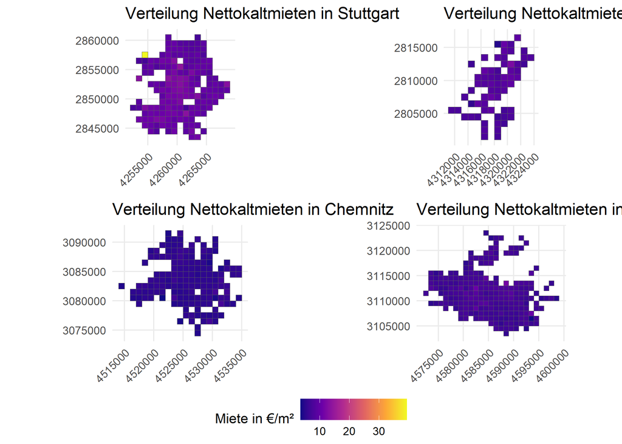

Antworten

Die Grafik für Stuttgart zeigt den hellsten Blauton, was darauf hinweist, dass diese Stadt die höchsten Mieten unter den vier betrachteten Städten aufweist. Der Mietpreis bewegt sich zwischen ca 7 euro und 40 euro Miete, im Schnitt aber um die 10 Euro, doch sticht in einem gelben Quadrat besonders hervor, das einen außergewöhnlich hohen Mietpreis von etwa 40 Euro signalisiert. Die Karte weist wenige Leerflächen auf, was auf eine dichte Besiedlung in Stuttgart hindeutet. Dies lässt darauf schließen, dass die Mietpreise in Stuttgart insgesamt gleichmäßig verteilt sind, mit nur einem signifikant teureren Stadtteil. Dieser Ausreißer könnte auf die gute Lage, die ausgezeichnete Infrastruktur und wahrscheinlich besonders hochwertige Neubauten zurückzuführen sein. Die generell hohen Mietpreise in Stuttgart können durch die Tatsache erklärt werden, dass Stuttgart als Landeshauptstadt von Baden-Württemberg eine stark nachgefragte Wohngegend darstellt. Der Stadtbereich profitiert von einer hervorragenden Infrastruktur mit mehreren Autobahnen, die in alle Richtungen führen, sowie einem effizienten Nah- und Fernverkehr. Hinzu kommt ein breites Spektrum an Arbeitsmöglichkeiten, insbesondere in renommierten Unternehmen. Diese Aspekte tragen alle zusammen dazu bei, die Mietpreise in Stuttgart zu erhöhen. Die große Spanne der Mietpreisen lässt sich durch sehr verschiedene Stadtteile erklären. Gerade die Wohnplätze der Innenstadt sind deutlich teurer, was natürlich auf die Lage zurückzuführen ist.

Ulm weist etwas niedrigere Mietpreise im Gegensatz zu Stuttgart auf, ist aber die Stadt mit den zweithöchsten Mieten im betrachteten Vergleich. Die Mietpreise sind innerhalb der Stadtteile relativ gleichmäßig verteilt, ohne auffällige Ausreißer. Es gibt zwei etwas dunklere Bereiche, die um die 4 bis 5 Euro pro Quadratmeter liegen, jedoch ist dies aufgrund der engen Verteilung der Mietpreise und der dadurch ähnlichen Farbtöne schwer aus der Grafik abzulesen. Die Karte zeigt mehrere Lücken, was darauf hindeutet, dass die Besiedlung in Ulm nicht besonders dicht ist und es mehrere unbewohnte Flächen gibt. Trotz seiner geringeren Größe zeigt Ulm im Durchschnitt höhere Mietkosten als Dresden und Chemnitz. Die Gründe dafür liegen in der ausgezeichneten Infrastruktur, den hochwertigen Bildungseinrichtungen und der attraktiven Wohnumgebung, auch in der Rolle als Grenzstadt zu Bayern. Diese Faktoren machen Ulm zu einem begehrten Wohnort, was die Nachfrage erhöht und dadurch die Mietpreise in die Höhe treibt.

Chemnitz hat die dunkelste Verfärbung und somit auch die niedrigsten Mietpreise und auch die kleinste Spanne zwischen den verschiednenen Stadtteilen. Jeder der Stadtteile weißt einen Mietpreis unter 10 Euro auf. die Dichte dagegen ist wieder recht hoch.

In Stuttgart, das in einer malerischen Hügellandschaft im Neckartal liegt, tragen die attraktiven Lagen mit Ausblick sowie die hervorragende Verkehrs- und Wirtschaftsstruktur zu hohen Mietpreisen bei. Die Stadt ist ein bedeutendes wirtschaftliches Zentrum mit einer starken Präsenz der Automobil- und Technologiebranchen, was die Nachfrage nach Wohnraum zusätzlich antreibt. Ulm, an der Donau gelegen und bekannt für das Ulmer Münster, weist eine ausgezeichnete Anbindung an Verkehrsknotenpunkte auf, insbesondere zwischen Stuttgart und München. Diese strategische Lage, kombiniert mit hochwertigen Bildungseinrichtungen und der Nähe zu Bayern, macht Ulm zu einem attraktiven Wohnort mit entsprechend steigenden Mietpreisen. Die Infrastruktur mit einem gut ausgebauten Nahverkehrsnetz und Zugverbindungen verstärken dieses Potenzial. Dresden, die Hauptstadt Sachsens, bietet reichhaltige kulturelle und historische Sehenswürdigkeiten. Die Stadt profitiert von einer strategisch günstigen Lage an der Elbe sowie einem robusten Verkehrs- und Bildungsangebot. Attraktive Stadtteile mit Zugang zu kulturellen Einrichtungen und Freizeitmöglichkeiten ziehen hohe Mietpreise an. Die wirtschaftliche Entwicklung Dresdens, insbesondere in Branchen wie Mikroelektronik und Biotechnologie, hat zur Nachfrage nach hochwertigem Wohnraum geführt. Chemnitz hingegen zeichnet sich durch seine industrielle Geschichte und kontinuierliche Transformation aus. Während sich bestimmte Stadtteile durch wirtschaftliche Herausforderungen auszeichnen, entwickelt sich die Stadt weiter und zieht neue Bewohner mit innovativen Projekten und einem sich erholenden Arbeitsmarkt an. Die Mietpreise sind tendenziell niedriger als in den anderen genannten Städten, was Chemnitz zu einer kostengünstigeren Alternative macht.

Die wirtschaftlichen Unterschiede zwischen Städten im Westen Deutschlands, wie Stuttgart und Ulm, im Vergleich zu denen im Osten, wie Dresden und Chemnitz, sind tief in der Geschichte und der wirtschaftlichen Entwicklung der Regionen verwurzelt. Im Westen wurden Städte wie Stuttgart und Ulm nach dem Zweiten Weltkrieg stark industrialisiert, was zu einer soliden wirtschaftlichen Basis führte. Stuttgart ist insbesondere bekannt für seine Automobilindustrie, hier sind Weltmarken wie Mercedes-Benz und Porsche ansässig. Diese Unternehmen ziehen weitere Dienstleistungs- und Zulieferfirmen an, wodurch ein stabiles Netzwerk von Arbeitsplätzen entstanden ist, das Fachkräfte aus ganz Deutschland und darüber hinaus anzieht. Diese hohe Nachfrage nach qualifizierten Arbeitskräften führt zu einer gesteigerten Nachfrage nach Wohnraum, und folglich zu höheren Mietpreisen. Ulm wiederum, als strategischer Knotenpunkt zwischen Stuttgart und München, profitiert von seiner Lage und seiner starken wirtschaftlichen Basis im Wissenschafts- und Technologiebereich. Die Universität Ulm und der Science Park ziehen sowohl Studenten als auch qualifizierte Arbeitskräfte an, was die Mietpreise ebenfalls beeinflusst. Die gut entwickelte Infrastruktur und die Nähe zu wichtigen Verkehrswegen wie der Autobahn A8 tragen zur Attraktivität der Stadt bei. Dresden und Chemnitz, beide im Osten Deutschlands gelegen, haben nach der Wiedervereinigung eine langsame, aber stetige wirtschaftliche Umstrukturierung erfahren. Dresden hat sich zu einem bedeutenden Zentrum für Mikroelektronik und Biotechnologie entwickelt, ein Standortvorteil, der Investitionen in den Arbeitsmarkt lockt. Die historische Architektur und die kulturellen Angebote Dresdens steigern oft die Attraktivität für neue Bewohner, obwohl diese Punkte noch im Kontext der gesamtwirtschaftlichen Entwicklung stehen. Chemnitz hingegen, mit seiner traditionsreichen Industriegeschichte, hat seit der Wiedervereinigung ebenfalls Herausforderungen bei der Anpassung an die neue Marktwirtschaft erlebt. Als weniger wirtschaftlich diversifizierte Stadt hat Chemnitz in den letzten Jahren Anstrengungen unternommen, um mit modernen Technologien und neuen Industrieprojekten aufzuholen. Diese Anpassungen beeinflussen die Arbeitsmarktsituation und führen zu einer unterschiedlichen Mietpreisdynamik im Vergleich zum Westen.Der Einfluss auf die Mietpreise ist eindeutig: Die stabileren und diversifizierteren Arbeitsmärkte in westdeutschen Städten wie Stuttgart und Ulm schaffen eine konstante Nachfrage nach Wohnraum, was höhere Mietpreise rechtfertigt. Umgekehrt befinden sich ostdeutsche Städte wie Dresden und Chemnitz noch im Prozess des wirtschaftlichen Wandels, was oft zu günstigeren Mietpreisen führt. Diese Unterschiede spiegeln sich in der Wohnraumverfügbarkeit, den infrastrukturellen Annehmlichkeiten und letztlich der Lebensqualität wider. Der anhaltende Transformationsprozess im Osten und die etablierte wirtschaftliche Stärke im Westen zeigen, wie wichtig kontinuierliche Investitionen und strategische Planungen für die Entwicklung der Infrastruktur und die Anpassung an den Arbeitsmarkt auf beiden Seiten sind. Diese wirtschaftlichen Dynamiken beeinflussen weiterhin die Attraktivität und Erschwinglichkeit des Wohnraums in diesen Regionen.

14. Nachdem Sie in Aufgabe 13 die Verteilung der Mieten der einzelnen Stadtteile visualisiert haben, sollten Sie in dieser Aufgabe den Anteil der Leerstandsquoten in den Stadtteilen der Städte “Stuttgart, Landeshauptstadt”, “Ulm, Universitätsstadt”, “Chemnitz, Stadt” und “Dresden, Stadt” veranschaulichen.

Erstellen Sie vier Grafiken, beschreiben und interpretieren diese. Gehen Sie insbesondere auf folgende Fragen ein:

- Was könnten Gründe sein, dass die Leerstandsquote in bestimmten Stadtteilen höher ist, als in anderen?
- Welche Besonderheiten fallen Ihnen bei diesen Städten auf? Auch im Hinblick auf ihre Erkenntnisse aus Aufgabe 13.
- Vergleichen Sie die Grafiken aus Aufgabe 13 und Aufgabe 14. Was könnte der Grund für die unterschiedlichen Muster sein?
- Welche Maßnahmen ergreifen Städte mit hohen Leerstandsquoten, um diese zu reduzieren?

*Hinweis:* Wenn Sie einheitliche Legenden für die Karten haben möchten und die vier Städte nebeneinander oder untereinander darstellen möchten, so empfiehlt sich das Paket `ggpubr` und dort der Befehl `ggarrange`.

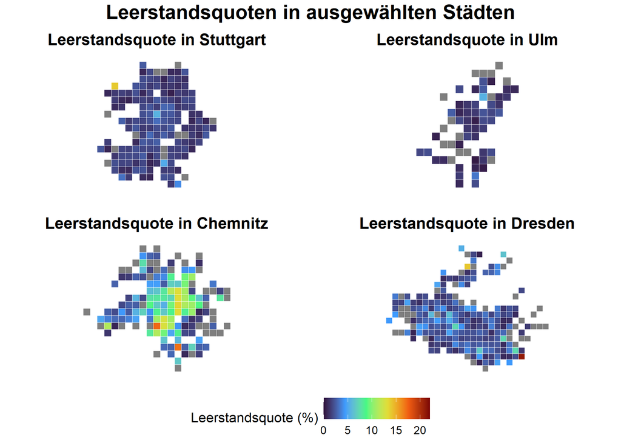

In Chemnitz gibt es viele Datenlücken, und die Leerstandsquoten sind insgesamt ungleichmäßig verteilt. Während die Stadtrandgebiete niedrigere Quoten aufweisen, sind die zentralen Stadtbereiche oft höher belastet, was überraschend sein mag, da die Mietpreise keine entsprechenden Unterschiede aufweisen. Gründe hierfür könnten in der industriellen Vergangenheit von Chemnitz liegen, da wirtschaftliche und demografische Umwälzungen diese zentralen Bereiche leerer gemacht haben. Oft ist auch in zentrale Gebiete weniger in Neubauten oder Modernisierungen investiert worden, während am Rand neuere und attraktivere Wohngebiete entstanden sind. Auffällig sind zwei Bereiche mit einer LEQ über 15 %, nicht korrelierend mit den Mietpreisen. Die Ursachen könnten in den oben genannten Punkten liegen. Insgesamt hat Chemnitz aber eine recht hohe LEQ. Nach der Wiedervereinigung erlebte Chemnitz einen erheblichen wirtschaftlichen Wandel, und der Verlust von Industrie hat die Nachfrage nach Wohnraum verringert. Die Anpassung an die Marktwirtschaft hatte ihre Herausforderungen, was zu einem Leerstand führte. Ein Mangel an modernisierten oder ansprechenden Wohnmöglichkeiten, die den Wohnbedürfnissen entsprechen, könnte ebenfalls zur LEQ beitragen.

Auch Dresden zeigt viele graue Quadrate ohne Informationen und eine gleichmäßige, jedoch nicht gleichverteilte LEQ. Einzelne Stadtteile weisen höhere Leerstände auf, aber die Mietpreise in diesen Gebieten sind im Allgemeinen niedriger, was auf minderwertige Wohnqualität oder Standorte hindeutet. Dresden hat einen markanten Punkt mit einer LEQ von über 20 % und weist somit die höchste LEQ aller vier Städte auf. Der Bauboom in Dresden, wie in vielen anderen Städten, könnte zeitweise mehr Wohnraum erzeugt haben, als die Nachfrage Schritt hält. Stadtteile könnten aufgrund von sozialen oder wirtschaftlichen Faktoren weniger gefragt sein, was zu höheren Leerständen führt. In Dresden variieren die Leerstandsquoten je nach Lage und Qualität der Wohnungen. Regionale Unterschiede in Wirtschaft, Arbeitsplatzangebot und Infrastruktur üben ebenfalls entscheidenden Einfluss auf das Stadtbild aus.

Städte mit hohen Leerstandsquoten setzen eine Reihe von Strategien ein, um den Leerstand zu verringern und die Attraktivität des Wohnraums zu steigern. Eine der häufigsten Maßnahmen ist die Förderung der Sanierung und Modernisierung von Wohnungen, um deren Qualität und Effizienz zu erhöhen, was letztlich die Nachfrage steigern kann. Durch gezielte Programme kann das Stadtbild aufgewertet und der Leerstand in älteren Gebäuden reduziert werden. Ebenso unterstützen Städte innovative Wohnbauprojekte, die nachhaltige und moderne Ansprüche erfüllen, um leerstehende Gebäude neu zu nutzen oder umzugestalten. Ein weiterer Ansatz ist die Umnutzung von ungenutzten Büro- oder Industrieräumen in Wohngebäude, um den Bedarf an Wohnraum in gefragteren Lagen zu decken.Zusätzlich investieren Städte in umfangreiche Stadtentwicklungsprojekte, die die Infrastruktur, wie öffentliche Verkehrsmittel, Parks, Schulen und Freizeiteinrichtungen, aufwerten, um ganze Stadtviertel attraktiver zu machen. Finanzielle Anreize und Steuervergünstigungen werden oft angeboten, um private Investoren und Immobilienbesitzer zu motivieren, in Renovierungen und Neubauten zu investieren und dadurch leerstehende Immobilien wieder verfügbar zu machen. Manche Städte fördern den Zuzug neuer Bewohner, etwa durch Anreize für Wissenschaftler, Fachkräfte oder Studierende, um die Nachfrage nach Wohnraum anzukurbeln.Die Anpassung der Mietpreise kann ebenfalls eine Rolle spielen. Durch Anreize oder Förderungen können die Preise so gestaltet werden, dass sie realistisch und für Mieter attraktiv sind, wodurch Leerstände vermieden werden. Darüber hinaus werden soziale Integrationsprojekte und Community-Building-Initiativen gefördert, um den sozialen Zusammenhalt zu stärken und die Lebensqualität in den Wohngebieten zu erhöhen. Durch diese ganzheitlichen Ansätze versuchen Städte, ein Gleichgewicht auf dem Wohnungsmarkt herzustellen und die nachhaltige Nutzung des städtischen Raums zu gewährleisten, um die Lebensqualität der Bewohner zu fördern und den Leerstand zu minimieren.

15. Die aktuellen Mietpreise und deren Entwicklungen hindern in Deutschland immer mehr Menschen daran, dass sie sich eine neue geeignete Wohnung suchen. Personen, die aufgrund ihrer aktuellen Lebenssituation sich nach einer neuen Wohnung umsehen, finden oft keine oder können sich diese nicht leisten. Doch worin liegen die Ursachen und Probleme?

Beantworten Sie hierzu folgende Fragen:

- Was versteht man unter dem Lock-in-Effekt, speziell in Bezug auf den Mietmarkt? Wer ist davon vor allem betroffen und warum?
- Gibt es aktuell Möglichkeiten, die vor allem diese “betroffenen” Personen haben, um an bezahlbaren Wohnraum zu gelangen?
- Worin liegen die Ursachen, dass Bestandsmieten (Mieten aus bestehenden Verträgen) und Angebotsmieten (Mieten aus Neuverträgen) so stark voneinander abweichen?

Gehen Sie in ihrer Argumentation auch auf die Grafiken und Ergebnisse der Aufgaben 11, 13 und 14 ein.

Der Lock-in-Effekt beschreibt eine Situation, in der Menschen trotz eines Bedarfs oder Wunsches, ihre Wohnsituation zu ändern, in ihrer aktuellen Wohnung bleiben, da die Kosten und Risiken eines Umzugs (insbesondere in Bezug auf Mietpreise) deutlich höher wären als die Vorteile einer neuen Wohnung.

Langzeitmieter profitieren oft von Bestandsmietpreisen, die oftmals unter den aktuellen Angebotsmieten liegen. Am meisten davon betroffen sind Familien, Rentner, Geringverdiener, Sozialhilfeempfänger und Pendler. Gerade diese Leute sind auf eine bezahlbare Wohnung angewiesen. Kurzfristige Maßnahmen, um an bezahlbaren Wohnraum zu kommen, gibt es einige, bspw. durch Wohngeld, staatliche Förderung, Umzug ins städtische Großraumgebiet, aber auch Zwischenmieten und Wohngemeinschaften. Jedoch bräuchten gerade diese Personengruppen Stabilität. Man nehme an, eine Familie müsste alle paar Monate umziehen; besonders mit kleinen Kindern kaum vorstellbar.

Langfristige Maßnahmen wären die Förderung des sozialen Wohnbaus, wie schon in A11 beschrieben, aber auch mehr Schutz für Mieter und für Immobiliengesellschaften gewisse Quoten, die sie erfüllen müssen. Darunter könnte man sich vorstellen, dass pro bestimmte Anzahl an vermieteten Wohnungen ein gewisser Teil an bspw. Familien mit Kindern vermietet werden muss. Momentane Möglichkeiten gibt es leider nicht allzu viele; diese beschränken sich wohl auf viele Umzüge und Wohnungen weit außerhalb der Stadt.

Die Abweichung von Bestandsmieten und Angebotsmieten liegt primär an der gesetzlichen Regulierung. Bei Bestandsmieten gibt es eine Kappungsgrenze, welche festlegt, um wie viel die Miete in einem bestimmten Zeitraum maximal ansteigen darf. Außerdem profitieren Bestandsmieter oft von Verträgen („Altverträge“), die für einen längeren Zeitraum abgeschlossen wurden. Bezüglich der Angebotsmieten spielt der Faktor des extremen Nachfrageüberschusses in den städtischen Regionen eine riesige Rolle. Hohe Mietpreise sind so problemlos möglich, was bei neuen Wohnungen besonders zu tragen kommt.

# Stadt vs. Land

Bisher haben Sie sich intensiv mit der Wohnsituation in Deutschland auseinandergesetzt und dabei insbesondere die Unterschiede zwischen Ost- und Westdeutschland betrachtet. Im Fokus standen dabei die Mietpreisentwicklung und die Rolle verschiedener Faktoren wie demografische Merkmale, Leerstandsquote, Eigentümerquote, sowie die Wohnfläche. Diese Analysen haben wertvolle Erkenntnisse über die regionale Dynamik des Mietmarkts geliefert.

Nun sollen Sie ihren Blickwinkel erweitern und den Fokus auf eine weitere Ebene der Analyse richten. Im Kern sollen Sie den Unterschied zwischen städtischen Regionen, insbesondere Großstädten, und ländlichen Gebieten untersuchen. Hierbei soll die Mietstruktur in diesen beiden Raumtypen analysiert werden, ob sich die Strukturen von Stadt und Land voneinander unterscheiden.

16. Betrachten Sie in einem ersten Schritt die Wohnungen abhängig ihres Alters. Erstellen Sie dazu eine passende Grafik, die die Verteilung der Wohnungen nach Altersgruppen für die Stadt `Stuttgart, Landeshauptstadt` (Landkreis: Stuttgart, Stadtkreis) im Vergleich zum `Alb-Donau-Kreis` und `Ostalbkreis` darlegt.

Beschreiben und interpretieren Sie ihre Grafik. Woran könnte es liegen, dass es in Stuttgart (in der Stadt) deutlich mehr Altbauwohnungen als auf dem Land gibt? Könnten politische Maßnahmen ihrer Ansicht nach helfen, dass auch in Großstädten mehr neue Wohnungen erbaut und zur Vermietung zur Verfügung gestellt werden?

*Hinweis 1:* Nutzen Sie für die Visualisierung einen Mosaik- oder ein “stacked” Balkendiagramm. Eine Idee, wie Sie das Ganze darstellen können, finden Sie [hier](https://r-graph-gallery.com/).

*Hinweis 2:* Für Stuttgart soll der komplette Landkreis (“Stadtkreis”) untersucht werden.

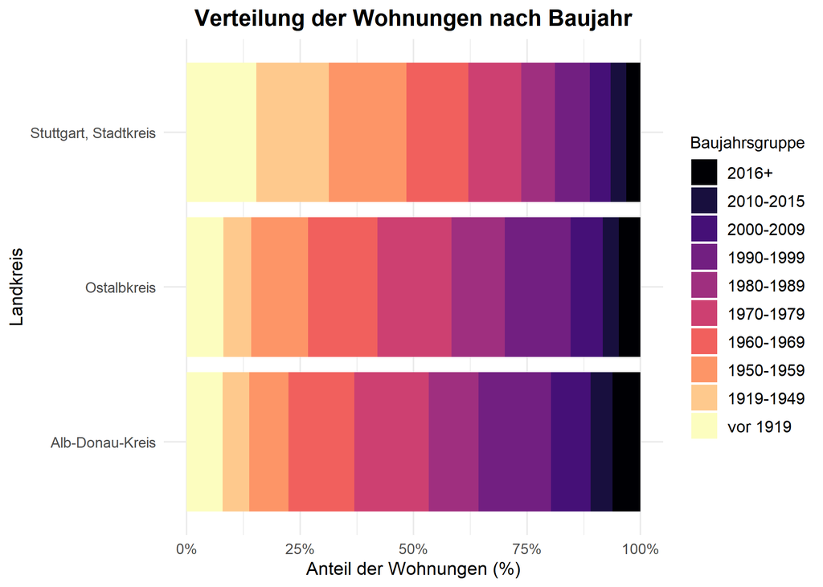

In einem weiteren Schritt sollen Sie nun die Mietpreise und deren Verteilung analysieren. Hierbei sollen Sie neben der Leerstands- und Eigentümerquote auch auf die Verteilung der Wohnungen nach deren Wohnfläche achten und diese untersuchen.

17 (a). Erstellen Sie zuerst eine Tabelle, die die durchschnittlichen Mietpreise mit der Leerstands- und Eigentümerquote darstellt. Was fällt ihnen dabei besonders auf? Beschreiben und interpretieren Sie ihre Tabelle.

17 (b). Erstellen Sie eine weitere Grafik, die die Verteilung der Wohnungen nach den einzelnen Wohnungsgrößen(<40m² bis >=200m²) abbildet. Stellen Sie darüber hinaus den durchschnittlichen Mietpreis je Landkreis in einer weiteren Grafik dar. Beschreiben und interpretieren Sie ihre Grafiken. Gehen Sie insbesondere auf die Frage ein, ob es Sinn macht sich vor allem den Ostalbkreis oder Alb-Donau-Kreis als ein Ganzes anzusehen und inwieweit überhaupt ein Vergleich zwischen Stadt und ländlicher Region möglich ist.

*Hinweis:* Hier sollen Sie erneut auf dieselben Städte und Landkreise aus Aufgabe 16 eingehen!

Durchschnittliche Mietpreise, Leerstands- und Eigentümerquoten

| Landkreis | Durchschnittswerte Mietpreis (€/m²) | Durchschnittswerte Leerstandsquote (%) | Durchschnittswerte Eigentümerquote (%) |
| --- | --- | --- | --- |
| Alb-Donau-Kreis | 6.37 | 5.34 | 71.44 |
| Ostalbkreis | 6.27 | 5.09 | 70.59 |
| Stuttgart, Stadtkreis | 10.39 | 3.46 | 31.15 |

Mit dieser Tabelle werden die Unterschiede zwischen Stadt und Land deutlich ersichtlich. Während die durchschnittlichen Mietpreise auf dem Land im Alb-Donau-Kreis (6,37 €/m²) und im Ostalbkreis (6,27 €/m²) nahezu identisch ausfallen, ist die Differenz zu Stuttgart als Großstadt mit 10,39 €/m² erheblich. Ein ähnliches Bild zeigt sich beim Vergleich der Leerstandsquote: Während im Alb-Donau-Kreis (5,34 %) und im Ostalbkreis (5,09 %) die Leerstandsquote vergleichsweise hoch ist, liegt sie in Stuttgart bei lediglich 3,46 %.Auch in Hinsicht auf die Eigentümerquote gibt es markante Unterschiede: Etwas mehr als 70 % der Wohnungsinhaber im Alb-Donau-Kreis (71,44 %) und im Ostalbkreis (70,59 %) wohnen in ihren eigenen Wohnungen, ganz im Gegensatz zu Stuttgart, wo lediglich 31,15 % der Menschen ihre eigenen Wohnungen beziehen.

Die in der Tabelle aufgezeigten Unterschiede lassen sich durch die Urbanisierung gut erklären. Städtische Gebiete wie Stuttgart ziehen durch bessere berufliche Perspektiven und Infrastruktur mehr Menschen an, was die Wohnraumnachfrage erhöht. Das Angebot an Wohnraum kann jedoch nicht mit der steigenden Nachfrage Schritt halten, was die Mietpreise nach oben treibt und die Leerstandsquote nach unten. Die steigende Nachfrage und der erhöhte Mietpreis treiben jedoch ebenfalls die Kosten für einen Kauf einer Wohnung deutlich nach oben, weshalb womöglich Banken, Immobilienfirmen oder private Investoren einen Großteil der Wohnungen besitzen und vermieten, womit die niedrige Eigentümerquote erklärt werden könnte.Die niedrigen Mietpreise und hohe Leerstandsquote in ländlichen Gebieten sind auf die geringere Wohnraumnachfrage zurückzuführen, da weniger Menschen in diese Regionen ziehen und viele junge Menschen in die Städte abwandern. Gleichzeitig fördern bezahlbare Immobilienpreise und kulturelle Präferenzen für Eigenheime eine hohe Eigentümerquote, da Wohneigentum auf dem Land leichter erreichbar ist und auch kulturell bevorzugt wird.

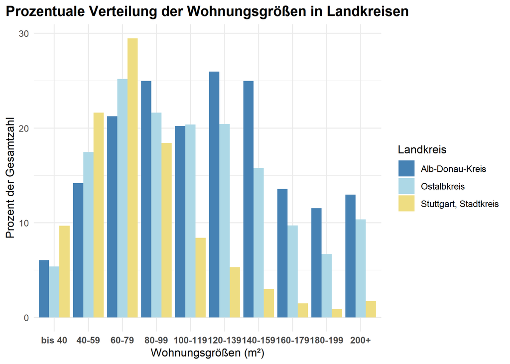

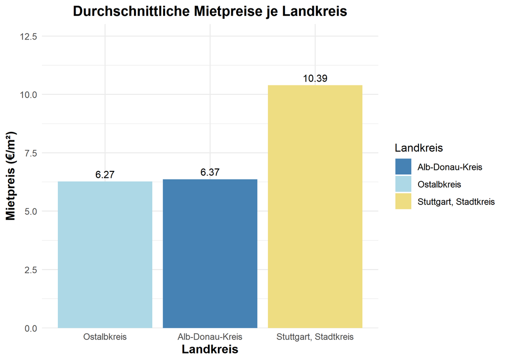

Beschreiben und interpretieren Sie ihre Grafiken. Gehen Sie insbesondere auf die Frage ein, ob es Sinn macht sich vor allem den Ostalbkreis oder Alb-Donau-Kreis als ein Ganzes anzusehen und inwieweit überhaupt ein Vergleich zwischen Stadt und ländlicher Region möglich ist.

# Zusatzfrage (optional)

Diese Frage ist von der Bearbeitung her etwas schwieriger. Bevor Sie sich an diese Aufgabe machen, sollten Sie sicherstellen, dass Sie alle vorherigen Fragen ausführlich beantwortet haben. Eine korrekte Beantwortung dieser Frage gibt einen Punktebonus von 3 Punkten (das Projekt umfasst insgesamt 30 Punkte, inkl. Screencast).

Nachdem Sie sich in den bisherigen Aufgaben ausführlich mit den allgemeinen Einflussfaktoren auf die Mietpreise befasst haben, rückt nun ein spezifischer Aspekt in den Fokus: die Rolle der Heizungen. Insbesondere werden Sie untersuchen, wie unterschiedliche Heizungsarten und -systeme die Mietpreise beeinflussen können. Diese Betrachtung ermöglicht es ihnen, die bisherigen Analysen zu verfeinern und den Zusammenhang zwischen energetischen Standards und der Entwicklung von Mietkosten genauer zu erfassen. Aufgabe 18 führt Sie somit zu einem weiteren zentralen Detail der Mietpreisentwicklung, das insbesondere vor dem Hintergrund steigender Energiepreise und der Relevanz nachhaltiger Wohnformen an Bedeutung gewinnt.

18. Lesen Sie den Datensatz `Heiztypen_Zensus.csv` ein und speichern diesen als `heiztypen` ab. Neben den Ihnen bekannten Variablen, finden Sie dort 6 weitere Variablen, die Auskunft über die Heizarten der jeweiligen Wohnung geben. Diese werden wie folgt beschrieben:
- HEIZTYP__1: Gebäude mit Heizungsart Fernheizung (Fernwärme) (Anzahl)
- HEIZTYP__2: Gebäude mit Heizungsart Etagenheizung (Anzahl)
- HEIZTYP__3: Gebäude mit Heizungsart Blockheizung (Anzahl)
- HEIZTYP__4: Gebäude mit Heizungsart Zentralheizung (Anzahl)
- HEIZTYP__5: Gebäude mit Heizungsart Einzel- oder Mehrraumöfen (auch Nachtspeicherheizung) (Anzahl)
- HEIZTYP__6: Gebäude mit Heizungsart Keine Heizung im Gebäude oder in den Wohnungen (Anzahl)

Erstellen Sie eine neue Spalte `heiztypen_gesamt`, welche die Summe über alle Heiztypen hinweg bildet. Bestimmen Sie weiterhin den Anteil der jeweiligen Heiztypen je Gemeinde (als Anteil aller Heizarten). Nun sollen Sie eine oder mehrere passende Grafik(en) erzeugen, die je nach durchschnittlicher Größe der Wohnungen die Anteile der verschiedenen Heizungsarten abbilden. Erstellen Sie weiterhin eine oder mehrere passende Grafik(en) die den Zusammenhang zwischen den Heizungsarten und den durschnittlichen Mietpreisen darstellt. Wiederum soll der Anteil der verschiedenen Heizungsarten abhängig der Mietpreise abgebildet werden.

Beschreiben und interpretieren Sie ihre Schaubilder und gehen Sie insbesondere auf folgende Frage ein:

- Gibt es einen Zusammenhang zwischen der Heizungsart und der Größe der Wohnungen?
- Gibt es einen Zusammenhang zwischen der Heizungsart und den Mietpreisen?
- Was könnten Gründe sein, warum in bestimmten Wohnungsgrößen eher bestimmte Heizungstypen eingebaut werden und andere nicht?
- Warum könnte es sein, dass bei manchen Heizungsarten die Mietpreise höher sind als bei anderen?
- Was könnte die Bundesregierung machen, um trotz neuer und moderner Heizungssysteme die Mietpreise nach oben hin zu beschränken?

*Hinweis 1:* Überlegen Sie sich, ob es ihrer Ansicht nach Sinn macht, die jeweiligen Wohnungsgrößen und durchschnittlichen Mietpreise in Segmente zu unterteilen.

*Hinweis 2:* Eine Möglichkeit die Beziehung zwischen Heizungsarten und Wohnungsgrößen bzw. Heizungsarten und Mietpreisen zu visualisieren wäre beispielsweise ein “stacked” oder “grouped” Balkendiagramm. Überlegen Sie sich, warum diese Form der Darstellung besonders gut geeignet wäre.

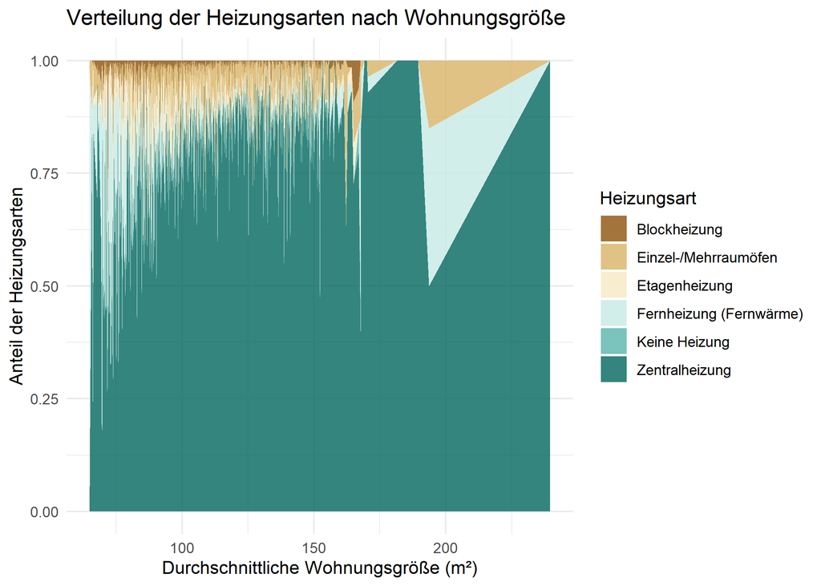

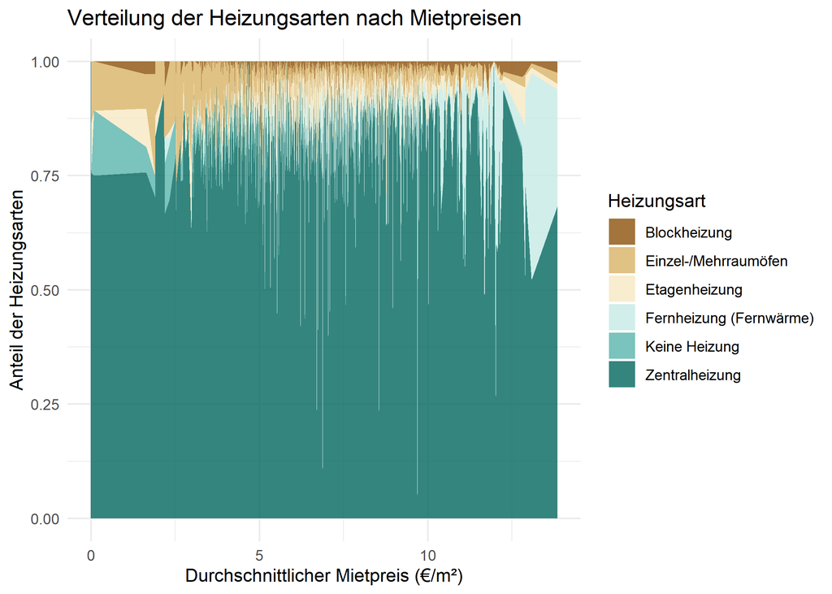

- Warum könnte es sein, dass bei manchen Heizungsarten die Mietpreise höher sind als bei anderen? - Was könnte die Bundesregierung machen, um trotz neuer und moderner Heizungssysteme die Mietpreise nach oben hin zu beschränken?

Für diese Aufgabe haben wir zwei Flächendiagramme geplottet, zum einen eine prozentuale Verteilung der Heizunsgarten in Abhängigkeit von der Wohnungsgröße und zum anderen in Abhängigkeit von der durchschnittlichen Miete pro Quadratmeter, je als Flächendiagramm.

Zu erwarten war, dass Zentralheizung bei nahezu jeder Wohnungsgröße gut vertreten ist, da es der “Default” der Heizunsgtypen ist, während Etagenheizung eher bei kleineren Wohnungen vorhanden ist, da es einfacher zu installieren ist. Bei allgemeiner Betrachtung der Verteilung der Heizungsarten nach Wohnungsgröße ist eine deutliche Korrelation zwischen Heizungsarten in Abhängigkeit von der Wohnungsgröße erkennbar. Es fällt auf, desto größer die Wohnung, desto größer die Verwendung von Fernwärme und Zentralheizung, während Einzel- und Mehrraumöfen, durchgehend zu einem geringeren Anteil vertreten ist. Zudem ist die Verteilung der Fernwärme sehr variabel je nach Wohnungsgröße, was damit zusammenhängt, dass Fernwärme nicht überall verfügbar ist und somit in manchen Gebieten eher vertreten und in anderen überhaupt nicht.

Anders als bei der Abhängigkeit von der Wohnungsfläche, zeigt sich bei der Verteilung der Heizungstypen zur durchschnittlichen Miete ein ausgeglichenes Bild über alle Preise hinweg. Jedoch fällt auf, dass im Niedrigpreissektor bis 5€/m^2 Einzel- und Mehrraumöfen, sowie keine Heizung öfters vertreten sind. Besonders überhaupt keine Heizung macht in der Preisklasse Sinn, da sich manche Leute die nicht viel Geld für eine Wohnung, tendenziell kein Geld für eine Heizung haben. Zentralheizungen bleiben hingegen die dominante Heizungsart in nahezu allen Preisklassen. Im gehobenen Preissegment, insbesondere in der Luxusklasse mit durchschnittlichen Mieten von etwa 12 bis 14 €/m², ist ein klarer Trend hin zur Fernwärme erkennbar. Fernwärme wird oft in modernen, energieeffizienten Gebäuden eingesetzt, die höhere Investitionskosten erfordern, was sich in den Mieten widerspiegelt.

Die Bundesregierung kann mit einem Mix aus Regulierung, Förderung und Infrastrukturmaßnahmen eingreifen, um den Preisdruck auf dem Mietmarkt zu begrenzen. Dabei sollte ein Gleichgewicht zwischen Klimaschutz, Investitionsförderung und soziale Gerechtigkeit gewahrt werden, um sowohl Vermieter als auch Mieter zu entlasten.

Wie Sie in der Aufgabe 15 gesehen haben, haben Ulm und Stuttgart, sowie Dresden und Chemnitz ähnliche Verhältnisse bezüglich der Verteilung der Mietkosten über die Stadt hinweg. Aufgrund dessen beschränken Sie sich bei dieser Aufgabe auf die Städte Stuttgart und Dresden. Hier sollen Sie sich die einzelnen Heizungsarten über die Stadtteile hinweg anschauen, wie sich diese verteilen und ob hier Ähnlichkeiten zur Mietpreissstrukur vorliegt. Weiterhin sind vor allem die Heizungsarten Fernwärme, Zentralheizung und Etagenheizung in viele deutschen Wohnungen größtenteils verbaut, weshalb Sie gerade deswegen diese drei Heiztypen genauer beleuchten und untersuchen sollen.

19. Deshalb sollten Sie sich in einem ersten Schritt [diese Geogitter-Daten für die verschiedenen Heinzungsarten vom statistischen Bundesamt herunterladen](https://www.zensus2022.de/static/Zensus_Veroeffentlichung/Zensus2022_Heizungsart.zip). Speichern Sie die zip-Datei im Ordner `Daten` ab. Nutzen Sie erneut den Datensatz shape_file aus der Aufgabe 4 und joinen Sie die Informationen zu den Heizungsarten über die Variablen `x_mp_1km` und `y_mp_1km`.

In ihrem Datensatz können Sie sehen, dass es Einträge mit “-” gibt. Diese sollen sie für alle Heizungstypen durch 0 ersetzen. Achten Sie auch darauf, dass über alle Heizungstypen hinweg die Werte als numeric vorliegen.

Erstellen Sie nun für die Heizungsarten “Fernheizung”, “Etagenheizung” und “Zentralheizung” eine neue Spalte mit dem Anteil des jeweiligen Heizungstyps an allen Heizungen (`Insgesamt_Heizungsart`) je Gemeinde. Schließlich sollen Sie nun für die drei genannten Heizungsarten eine Karte erzeugen, welche den Anteil je Gitterebene im Stadtbezirk darstellt.

Beschreiben und interpretieren Sie ihre Grafiken. Berücksichtigen Sie dabei insbesondere folgende Fragen:

- Wo liegen Besonderheiten oder Muster in beiden Städten?
- Gibt es in Stuttgart und Dresden Stadtteile, bei denen bestimmte Heizungstypen in Einklang mit den Mietpreisen stehen, genauer gesagt, welche Heizungsarten korrelieren mit höheren oder niedrigeren Mietpreisen? Vergleichen Sie dazu die Ergebnisse aus Aufgabe 15.
- Was könnten Gründe sein, dass in bestimmten Stadtteilen vorwiegend eine bestimmte Form der Heizung eingebaut ist?
- Gibt es Unterschiede zwischen Ost- und Westdeutschland?
- Haben die Städte Stuttgart oder Dresden in den letzen Jahren Modernisierungen angestoßen oder Neuerungen umgesetzt und finanziell unterstützt, sodass es dort zu größeren Anpassungen bei der Heizungstechnik kam?

*Hinweis 1:* Sie sollen insgesamt für jede Stadt (Stuttgart und Dresden) drei verschiedene Karten erzeugen.

*Hinweis 2:* Achten Sie auf eine sinnvolle Einteilung und Darstellung in den Karten. Nutzen Sie die Karten aus vorherigen Aufgaben als Hilfestellung.

Abschließend sollen Sie die Zusatzaufgabe noch einmal rekapitulieren und einige Fragen dazu beantworten.

20. Sie sollen sich noch einmal bewusst werden, was Sie in den vorherigen Aufgaben analysiert haben und in welcher Form ihre Ergebnisse anwendbar und verallgemeinbar sind. Beantworten Sie dazu Frage 1 und 2.

Frage 1: Betrachten Sie hierzu noch einmal exemplarisch die Städte Stuttgart und Dresden.

- Sind die Zusammenhänge zwischen Mietpreisen in den Städten und sozioökonomischer Faktoren vor allem auf Unterschiede zwischen den Städten oder auf Unterschiede innerhalb der Stadt zurückzuführen. Bei welchen Faktoren ist dies der Fall, wo nicht?
- Wie kann der Staat im Hinblick auf die unterschiedlichen Heizungsarten in den Städten eingreifen, um Wohnraum preiswerter zu gestalten?

Frage 2: Schauen Sie sich noch einmal die Verteilung der Heizungsarten (Fern-, Etagen- und Zentralheizungen) für Stuttgart und Dresden in Aufgabe 19 an. Betrachten Sie im Vergleich dazu ihre Grafik aus Aufgabe 8, sowie ihre Tabelle in Aufgabe 13?

- Was fällt Ihnen hier auf?
- Gibt es bestimmte Heizungstypen, die nur in alten oder neuen Wohnungen vorkommen?
- Welche Schlüsse würden Sie ziehen, die mit Handlungen der Politik einhergehen?